# 07. Multinomial logistic regression modelling

Author

David Ingerslev

Published

May 17, 2026

# Prepare

```python
# Setup code
import pandas as pd
from python_scripts import setup
from python_scripts import services
from python_scripts import helper
df, dffp = setup.setup(verbose=False)

from python_scripts import distinct_pathways
dpw_pls = distinct_pathways.get_distinct_pathways_routes(dffp)
qrows = dpw_pls["rt_end_cat"] == "[Not ended or invalid end reason]"
dpw_pls.loc[dpw_pls.pl_end_dt > distinct_pathways.dpw_end_dt, ["pl_end_dt", "pl_end_reason", "dur"]] = pd.NA
dpw_pls.loc[qrows, "rt_end_cat"] = dpw_pls.loc[qrows, "pl_end_dt"].isna().map({True: "[Not ended]", False: "Missing data/error"})
dpw_pls["rt_end_cat"] = dpw_pls["rt_end_cat"].str.replace("To care/hosp.", "To care/hospital")
dpw_rt_starts = dpw_pls.groupby("route_id").head(1)
dpw_rt_ends = dpw_pls.groupby("route_id").tail(1)
dpw_clis = dpw_pls.groupby(["o_cli_id"]).head(1)  # 1 duplicate client but first entry has more detailed answers

import matplotlib
import matplotlib.pyplot as plt
matplotlib.rcParams.update({
    'figure.figsize': (6.2, 4.1),
    'font.size': 12,
    'figure.constrained_layout.use': True
})

asset_themes = {"opaque": "assets_output/",
                "transparent_lightbg": "assets_transparent_lightbg/",
                "transparent_darkbg": "assets_transparent_darkbg/"}
assets_output = asset_themes["opaque"]
output_dir = assets_output
transparent = False
excel_output = {}
dpw_pls_orig = dpw_pls
odds_r_tables = []
figure_major_i = 7
figure_minor_i = 0

def get_frequencies(series, sort=True, dropna=True, dropna_pct=True):
    n = series.value_counts(sort=sort, dropna=dropna).rename("n")
    pct = 100 * series.value_counts(sort=sort, dropna=(dropna or dropna_pct), normalize=True).rename("pct")
    fq_tbl = pd.concat([n, pct], axis=1)
    return fq_tbl
```

## Collect dependent variables

```python
dv_dict = {}
#####################################
# 3.1 Entry point into BAHSA services
#####################################
rt_entries = dpw_rt_starts.copy()
rt_entries["pathway"] = rt_entries["svc_type_short"]
rt_entries["pathway_type"] = (rt_entries["pathway"] == "Substance Misuse Pathway").map({True: "Substance Misuse", False: "Homelessness"})
dv_dict["Entry point into BAHSA services (pathway type and level)"] = (
    rt_entries[["route_id", "pathway_type", "pathway_level"]].set_index("route_id"))
#################################################
# 3.1.1 Entry point into BAHSA: pathway and level
#################################################
rt_entries = dpw_rt_starts.copy()
print(f"Routes: {len(rt_entries):,}")
rt_entries["pway_and_lvl"] = rt_entries["svc_typelvl"]
dv_dict["Entry point into BAHSA services (pathway and level)"] = (
    rt_entries[["route_id", "pway_and_lvl"]].set_index("route_id"))
#####################################
# 3.2 Route outcomes after 3.08 years
#####################################
periodMult = {"d": 1, "m": 365.25/12, "y": 365.25}
years = periodMult["y"]
time_measure = pd.Timedelta(days=(3.08 * years))
dpw_rt_ends = dpw_pls.groupby("route_id").tail(1)
dpw_rt_ends = dpw_rt_ends.set_index("route_id", drop=False)
end_cols_to_drop = dpw_rt_ends.columns[
    (
        dpw_rt_ends.columns.isin(["gap", "dur"])
        | dpw_rt_ends.columns.str.startswith("prev_")
        | dpw_rt_ends.columns.str.startswith("vac_")
        | dpw_rt_ends.columns.str.startswith("pl_")
    )]
dpw_routes = dpw_rt_ends.drop(columns=end_cols_to_drop)
dpw_routes["rt_start_dt"] = dpw_rt_starts.set_index("route_id")["pl_start_dt"].rename("rt_start_dt")
dpw_routes["rt_end_dt"] = dpw_rt_ends["pl_end_dt"].rename("rt_end_dt")
# Set up map from categories to outcomes
rt_outcomes_map = {
    'Independent accommodation': ['To social housing', 'To private rented'],
    'Insecure outcome': ['To friends/family', 'Custody', '[Not ended]', 'To care/hospital', 'To external supported'],
    'Returned to homelessness': ['Evicted', 'Abandoned'],
    'Died': ['Died'],
    # '_excluded': ['Other', 'Missing data/error']
}
rt_end_cat_map = {cat: outcome for outcome in rt_outcomes_map.keys() for cat in rt_outcomes_map[outcome]}
dpw_rt_outcomes = dpw_routes[
    # Only include routes where there has been long enough for the outcome to happen
    (dpw_routes["rt_start_dt"] <= distinct_pathways.dpw_end_dt - time_measure)
    # Only include routes that have a rt_end_cat that corresponds to an outcome
    & (dpw_routes["rt_end_cat"].isin(rt_end_cat_map.keys()))]
dpw_rt_outcomes["rt_outcome"] = dpw_rt_outcomes["rt_end_cat"].map(rt_end_cat_map)
# Still being in supported accommodation is generally an insecure outcome
dpw_rt_outcomes.loc[
    (dpw_rt_outcomes["rt_end_dt"] > (dpw_rt_outcomes["rt_start_dt"] + time_measure)),
    "rt_outcome"] = "Insecure outcome"
# But being in level 3 or 4 of the homelessness pathways in self-contained (not shared)
# means having your own flat with support staff occasionally visiting, i.e. similar
# to independent accommdoation
dpw_rt_timemeasure_dt = (dpw_rt_outcomes["rt_start_dt"] + time_measure).rename("rt_timemeasure_dt")
rt_pls = dpw_pls.join(dpw_rt_timemeasure_dt, on="route_id", how="inner")
rt_pls_at_timemeasures = rt_pls[(rt_pls["pl_start_dt"] < rt_pls["rt_timemeasure_dt"])
                                & (
                                    rt_pls["pl_end_dt"].isna()
                                    | (rt_pls["pl_end_dt"] > rt_pls["rt_timemeasure_dt"])
                                )].set_index("route_id")
dpw_rt_outcomes.loc[
    (dpw_rt_outcomes["rt_end_dt"] > (dpw_rt_outcomes["rt_start_dt"] + time_measure))
    & (rt_pls_at_timemeasures["pathway_level"].isin(["3", "4"]))
    & (rt_pls_at_timemeasures["shared"] == "No"),
    "rt_outcome"] = "Independent accommodation"
dv_dict["Route outcomes after 3.08 years"] = (
                          dpw_rt_outcomes[["route_id", "rt_outcome"]].set_index("route_id"))
#######################################################################
# 3.3 Outcomes at a period of time after a person's first route started
#######################################################################
# dpw_cli_outcomes is the dpw_rt_outcome that is active after the measured time since the person's first route started
time_measure = pd.Timedelta(days=(3.08 * years))
# Relevant date for each client is their first route start date plus the time measure period
dpw_cli_timemeasure_dt = (dpw_rt_outcomes
                          .set_index("o_cli_id")
                          .groupby("o_cli_id")
                          .head(1)
                          ["rt_start_dt"]
                          + time_measure).rename("cli_timemeasure_dt")
dpw_cli_outcomes = dpw_rt_outcomes.join(dpw_cli_timemeasure_dt, on="o_cli_id").set_index("o_cli_id")
# Select the latest route that started before the outcome date
dpw_cli_outcomes = ((dpw_cli_outcomes[dpw_cli_outcomes["rt_start_dt"] <= dpw_cli_outcomes["cli_timemeasure_dt"]])
                    .groupby("o_cli_id").tail(1)).rename(columns={"rt_outcome": "cli_outcome"})
cli_pls = dpw_pls.join(dpw_cli_timemeasure_dt, on="o_cli_id")
cli_pls_at_timemeasures = cli_pls[(cli_pls["pl_start_dt"] < cli_pls["cli_timemeasure_dt"])
                                  & (
                                      cli_pls["pl_end_dt"].isna()
                                      | (cli_pls["pl_end_dt"] > cli_pls["cli_timemeasure_dt"])
                                  )].set_index("o_cli_id")
# Still being in supported accommodation is generally an insecure outcome
dpw_cli_outcomes.loc[cli_pls_at_timemeasures.index, "cli_outcome"] = "Insecure outcome"
# But being in level 3 or 4 of the homelessness pathways in self-contained (not shared)
# means having your own flat with support staff occasionally visiting, i.e. similar
# to independent accommdoation
equiv_ind_at_time = cli_pls_at_timemeasures[
    (cli_pls_at_timemeasures["shared"] == "No")
    & cli_pls_at_timemeasures["pathway_level"].isin(["3", "4"])]
dpw_cli_outcomes.loc[equiv_ind_at_time.index, "cli_outcome"] = "Independent accommodation"
dpw_cli_outcomes["cli_start_dt"] = (dpw_rt_starts.set_index("o_cli_id")
                                    .groupby("o_cli_id").head(1)["pl_start_dt"])
dpw_cli_outcomes["cli_end_dt"] = (dpw_rt_ends.set_index("o_cli_id")
                                  .groupby("o_cli_id").tail(1)["pl_end_dt"])
dv_dict["Outcomes 3.08 years after a person's first route started"] = (
                          dpw_cli_outcomes[["cli_outcome"]])
##############################################
# 3.4 Returning to use services multiple times
##############################################
dpw_clis = dpw_pls.groupby(["o_cli_id"]).head(1).set_index("o_cli_id")
dpw_clis["multiple_returns"] = (dpw_rt_starts.groupby(['o_cli_id']).size() >= 3).rename("multiple_returns")
dv_dict["People with multiple returns during 7.5 yrs"] = (
                          dpw_clis[["multiple_returns"]])
################################
# 3.5 Using services longer-term
################################
durations = dpw_pls.set_index(["o_cli_id", "route_id"])[["dur", "pl_start_dt"]]
durations["dur_days"] = durations["dur"].dt.days
durations["dur_days"] = durations["dur_days"].fillna(1 + (distinct_pathways.dpw_end_dt - durations.pl_start_dt).dt.days)
durations = durations.drop(columns=["dur", "pl_start_dt"]).groupby(["o_cli_id", "route_id"]).sum()
# Set threshold to top 10% of route durations
longer_term_threshold_days = durations.quantile(0.9)
dpw_clis = dpw_pls.groupby(["o_cli_id"]).head(1).set_index("o_cli_id")
dpw_clis["has_longer_term_rt"] = ((durations > longer_term_threshold_days)
                                  .groupby("o_cli_id").any())
dv_dict["People with a route in top 10% of route durations"] = (
                          dpw_clis[["has_longer_term_rt"]])
######################################################################
# 3.6 Returns within 2 years after moving to independent accommodation
######################################################################
# Note: Not enough returns after moves to independent accommodation to analyse much further.
# time_measure options: ['90d', '6m', '15m', '18m', '2y', '5y']
time_measure = "2y"
time_offset = distinct_pathways.stable_offsets[time_measure]
return_col = f"after_rt_ret_within_{time_measure}"
eligible_route_ends = dpw_rt_ends[
    # Only include routes that have a rt_end_cat that corresponds to independent accommodation
    dpw_rt_ends["rt_end_cat"].isin(["To social housing", "To private rented"])
    # Only include routes where there has been long enough for the outcome to happen
    & (dpw_rt_ends["pl_end_dt"] < distinct_pathways.dpw_end_dt - time_offset)]
dv_dict["Returns within 2 years after moving to independent accommodation"] = (
                          eligible_route_ends[["route_id", return_col]].set_index("route_id"))
#########################################
# 3.7 Outcomes from individual placements
#########################################
import numpy as np
from python_scripts import routes
pl_excluded = {}
pl_end_cat_map = routes.get_end_cats_map()
pl_outcomes = dpw_pls.set_index("vac_id")
pl_outcomes["pl_end_cat"] = pl_outcomes["pl_end_reason"].map(pl_end_cat_map)
next_pls = (dpw_pls.loc[dpw_pls["prev_vac_id"].notna()]
            .rename(columns={"vac_id": "next_vac_id", "prev_vac_id": "vac_id", "svc_type_short": "pathway"})
            .set_index("vac_id"))
next_pls["pathway"] = next_pls["pathway"].cat.remove_unused_categories()
pl_outcomes.loc[next_pls.index, "pl_end_cat"] = "Internal move"
pl_outcomes.loc[dpw_pls.loc[dpw_pls["prev_svc_id"] == dpw_pls["svc_id"], "prev_vac_id"].values, "pl_end_cat"] = "Internal move: same service"
pl_outcomes["pathway"] = pl_outcomes["svc_type_short"].cat.remove_unused_categories()
pl_outcomes["pathway_type"] = (pl_outcomes["pathway"] == "Substance Misuse Pathway").map({True: "Substance Misuse", False: "Homelessness"})
pl_outcomes["ended"] = pl_outcomes["pl_end_dt"].isna().map({True: "Current", False: "Ended"})
level_diff = (pl_outcomes.loc[pl_outcomes["pl_end_cat"] == "Internal move", ["pathway", "pathway_level"]]
              .join(next_pls[["pathway", "pathway_level"]].add_prefix("next_"))
              .assign(level_diff=lambda df: df[["pathway_level", "next_pathway_level"]]
              .astype("Int64").diff(axis=1).iloc[:, -1]))
# Difference in level is meaningful except that moves to/from SU pathway are different..
pl_outcomes = pl_outcomes.join((level_diff[["next_pathway_level", "level_diff"]]
                                .where((level_diff["pathway"] == level_diff["next_pathway"])
                                       | (level_diff["pathway"] != "Substance Misuse Pathway")
                                       | (level_diff["next_pathway"] != "Substance Misuse Pathway"))))
pl_outcomes.loc[pl_outcomes["level_diff"].notna(), "pl_end_cat"] = (
    "Internal move: " + np.sign(pl_outcomes.level_diff).map({-1: "backwards", 0: "sideways", 1: "forwards"})
)
# Exclude 738 placements that have not ended
pl_outcomes = pl_outcomes[pl_outcomes["dur"].notna()]
# Exclude 42 0-day placements
pl_outcomes = pl_outcomes[pl_outcomes["dur"] > pd.Timedelta(days=0)]
pl_outcomes_map = {
    'Independent accommodation': ['To social housing', 'To private rented'],
    'Insecure outcome (external)': ['To friends/family', 'Custody', '[Not ended]', 'To care/hospital', 'To external supported'],
    'Returned to homelessness': ['Evicted', 'Abandoned'],
    'Died': ['Died'],
    # '_excluded': ['Other', 'Missing data/error']
}
pl_end_cat_map = {cat: outcome for outcome in pl_outcomes_map.keys() for cat in pl_outcomes_map[outcome]}
pl_outcomes["pl_outcome"] = pl_outcomes["pl_end_cat"].map(pl_end_cat_map)
pl_outcomes.loc[
    pl_outcomes["pl_end_cat"].fillna("").str.startswith("Internal move"),
    "pl_outcome"] = pl_outcomes["pl_end_cat"]
# Exclude 1,310 moves within the same service
```

```python
pl_outcomes_excl_same_svc = pl_outcomes[pl_outcomes["pl_end_cat"] != "Internal move: same service"]
# Exclude 277 moves due to end reasons: 53 missing reaons, 200 "Other"
# TODO: Should "Other" really be excluded?
pl_outcomes_excl_same_svc = pl_outcomes_excl_same_svc[pl_outcomes_excl_same_svc["pl_outcome"].notna()]
dv_dict["Outcomes from individual placements"] = (
                              pl_outcomes_excl_same_svc[["pl_outcome"]])
dv_dict_desc = list(dv_dict.keys())
dv_dict_cats = {k: list(v.iloc[:, 0].astype("string").fillna("<N/A>").unique()) for k, v in dv_dict.items()}
display(dv_dict_desc)
```

Routes: 5,072

```
['Entry point into BAHSA services (pathway type and level)',
 'Entry point into BAHSA services (pathway and level)',
 'Route outcomes after 3.08 years',
 "Outcomes 3.08 years after a person's first route started",
 'People with multiple returns during 7.5 yrs',
 'People with a route in top 10% of route durations',
 'Returns within 2 years after moving to independent accommodation',
 'Outcomes from individual placements']
```

## Collect independent variables

```python
from collections import defaultdict
dpw_pls = dpw_pls_orig
# Add route entry point as an IV as well as a DV
tdf = dv_dict["Entry point into BAHSA services (pathway type and level)"]
rt_entry_point = (tdf["pathway_type"].map({"Homelessness": "H ", "Substance Misuse": "SU "})
                  + tdf["pathway_level"].astype("string")).rename("rt_entry_point")
dpw_pls = dpw_pls.join(rt_entry_point, on="route_id")
# Age category at year of first route during studied period
dpw_pls["gender"] = dpw_pls["gender"].map({
    "Male": "Male", "Female": "Female", "Don't Know": "_Unknown",
    "Prefer not to say": "_Unknown", "Transgender": "Non-Binary",
    "Non-Binary": "Non-Binary"
})
dpw_pls["age_cat"] = (dpw_pls["pl_start_dt"].dt.year - dpw_pls["yob"]>= 35).map({True: "35+", False: "34-"})

dpw_pls["global_majority"] = dpw_pls["ethnicity"].map(defaultdict(
    lambda: True,
    {
      "English/Welsh/Scottish/Northern Irish/British": False, "White British": False,
      "White Other Origin": False, "Any other White background": False, "White European": False,
      "Eastern European": False, "Turkish": False, "White Irish": False, "Irish": False,
      "White Gypsy/Irish Traveller": False, "Gypsy (inc English, Scottish or Roma Gypsy) or Irish Traveller": False,
      "Don't know": pd.NA, "Prefer not to say": pd.NA, "Refused to answer question": pd.NA
    }))
eth_dtl_map = {
    "White British": [
        "English/Welsh/Scottish/Northern Irish/British"
    ],
    "Unknown": [
        "Don't know",
        "Prefer not to say",
        "Refused to answer question"
    ],
    "Black/Black British - African": [
        "African (non Somali)",
        "Somali",
        "Black/Black British - Somali",
        "Black or Black British Ghanaian"
    ],
    "Black/Black British - Caribbean": [
        "Caribbean"
    ],
    "White Other": [
        "White Other Origin",
        "Any other White background",
        "White Irish",
        "Irish",
        "White European",
        "Eastern European",
        "Turkish"
    ],
    "Mixed/Dual Heritage - White+Black Caribbean": [
        "White and Black Caribbean"
    ],
    "Black/Black British - Other": [
        "Black/Black British - Other",
        "Any other Black/African/Caribbean background"
    ],
    "Arab": [
        "Iranian",
        "Iraqi",
    ],
    "Asian/Asian British": [
        "Asian/Asian British - Other",
        "Pakistani",
        "Bangladeshi",
        "Asian/Asian British - Chinese",
        "Asian/Asian British - Bangladeshi",
        "Asian/Asian British - Indian",
        "Indian",
        "Asian/Asian British - Asian African",
        "Chinese",
        "Asian/Asian British - Pakistani",
        "Asian or Asian British Sri Lankan",
        "Any other Asian background",
    ],
    "Any other Mixed/multiple ethnic background": [
        "Mixed/Dual Heritage - White+Asian",
        "Mixed/Dual Heritage - Other",
        "White and Asian",
        "Mixed/Dual Heritage - White+Chinese"
    ],
    "Mixed/Dual Heritage - White+Black African": [
        "White and Black African (non Somali)"
    ],
    "Other": [
        "Any other ethnic group",
        "Kurdish"
    ],
    "White Gypsy/Irish Traveller": [
        "Gypsy (inc English, Scottish or Roma Gypsy) or Irish Traveller"
    ]
}
mapper = {k: v for v, k in pd.Series(eth_dtl_map).explode().items()}
dpw_pls["ethnicity_detailed"] = dpw_pls["ethnicity"].replace(mapper).astype("string").astype("category")
eth_grp_map = {
    "White": [
        "White British",
        "White Other",
        "White Gypsy/Irish Traveller",
    ],
    "Black": [
        "Black/Black British - African",
        "Black/Black British - Caribbean",
        "Black/Black British - Other",
    ],
    "Mixed Heritage": [
        "Mixed/Dual Heritage - White+Black African",
        "Mixed/Dual Heritage - White+Black Caribbean",
        "Any other Mixed/multiple ethnic background",
    ]
}
mapper = {k: v for v,k in pd.Series(eth_grp_map).explode().items()}
dpw_pls["ethnicity_grouped"] = dpw_pls["ethnicity_detailed"].replace(mapper).astype("string").astype("category")
dpw_pls["lgbtq_plus"] = dpw_pls["sexual_orientation"].map({
    "Bi-sexual": True, "Gay/Lesbian": True, "other": True, "Lesbian": True,
    "Heterosexual": False, "Don't Know": pd.NA, "Rather not state": pd.NA,
})
dpw_pls["uk_immigration_status"] = dpw_pls["uk_immigration_status"].map({
    "Other Protection Leave to Remain": "Non-EEA National",
    "Indefinite Leave to Remain": "Non-EEA National",
    "Other Non-EEA National": "Non-EEA National",
    "Limited Leave to Remain": "Non-EEA National",
    "EEA National": "EEA National",
    "UK/Irish National": "UK/Irish National",
})
ref_cats = dpw_pls["ref_agency"].cat.categories
ref_cat_map = {
    "Local authority (Housing Options)": ["B.C.C. Homelessness Prevention Team"],
    "Local authority (_other)": list(ref_cats[ref_cats.str.startswith(("B.C.C", "Bcc"))
                                    & (ref_cats != "B.C.C. Homelessness Prevention Team")]),
    "Service provider (rough sleeping and SH)": ["St. Mungo's", "St Mungo's", "Outreach"],
    "Service provider (SU pathway, prison wk)": ["A.R.A"],
    "Service provider (_other SH)": ["E.C.H.G. Riverside", "Elim", "Livewest", "Missing Link", "Places For People",
                                    "Salvation Army", "Second Step", "Self Help"]
}
ref_cat_map["_Others"] = ref_cats[~ref_cats.isin(sum(list(ref_cat_map.values()), []))]
ref_agency_mapper = {k: v for v, k in pd.Series(ref_cat_map).explode().items()}
dpw_pls["referral_agency"] = (dpw_pls["ref_agency"].map(ref_agency_mapper)
                              .fillna("_[Missing data]"))
support_need_cols = {
    "hsn_prison_leaveron_probationrisk_of_offending": "offending",
    "hsn_physical_health": "physical_health",
    "hsn_mental_health": "mental_health",
    "hsn_rough_sleeper": "rough_sleeping",
}
for hsn, ch_str in support_need_cols.items():
    dpw_pls[ch_str] = dpw_pls[hsn].astype("boolean")
gendered_support_need_cols = {
    "hsn_sex_working": "sex_working",  # only women recorded as sex working
    "hsn_risk_of_violenceabuse_victim": "risk_violence_abuse",
    "hsn_risk_of_exploitation": "risk_exploitation",
}
for hsn, ch_str in gendered_support_need_cols.items():
    dpw_pls[f"women_{ch_str}"] = dpw_pls[hsn].where(dpw_pls["gender"] == "Female")
    dpw_pls[f"men_{ch_str}"] = dpw_pls[hsn].where(dpw_pls["gender"] == "Male")
    dpw_pls[ch_str] = dpw_pls[hsn]
dpw_pls["hsn_drug_or_alcohol_use"] = (dpw_pls["hsn_drug_use"].astype("boolean")
                                      | dpw_pls["hsn_alcohol_use"].astype("boolean"))
dpw_pls["multiple_disadvantage"] = (  # Current support needs for 3 out of 5 SMD dimensions
  dpw_pls[["hsn_prison_leaveron_probationrisk_of_offending",
           "hsn_drug_or_alcohol_use",
           "hsn_risk_of_violenceabuse_victim",
           "hsn_mental_health"
           ]].assign(hsn_homelessness=True).astype("boolean").sum(axis=1, skipna=False) >= 3
  )
dpw_pls["substance_use"] = dpw_pls["hsn_drug_or_alcohol_use"]
dpw_pls["pl_duration_weeks"] = (dpw_pls["pl_end_dt"]
                                .fillna(distinct_pathways.dpw_end_dt + pd.Timedelta(days=1))
                                .sub(dpw_pls["pl_start_dt"])
                                .dt.days
                                .div(7)
                                )
dpw_pls["pl_prev_dur_sum_weeks"] = dpw_pls.groupby("route_id")["pl_duration_weeks"].cumsum() - dpw_pls["pl_duration_weeks"]
dpw_pls["rt_duration_weeks"] = dpw_pls.groupby("route_id")["pl_duration_weeks"].transform(sum)
dpw_rt_starts = dpw_pls.groupby("route_id").head(1)
dpw_rt_ends = dpw_pls.groupby("route_id").tail(1)
dpw_clis = dpw_pls.groupby(["o_cli_id"]).head(1)  # 1 duplicate client but first entry has more detailed answers
characteristics = [
    "pl_duration_weeks",
    "pl_prev_dur_sum_weeks",
    "rt_duration_weeks",
    "rt_entry_point",
    "gender",
    "global_majority",
    "ethnicity_grouped",
    "ethnicity_detailed",
    "age_cat",
    "lgbtq_plus",
    "offending",
    "physical_health",
    "mental_health",
    "substance_use",
    "multiple_disadvantage",
    "rough_sleeping",
    "sex_working",
    "women_sex_working",
    "men_sex_working",
    "risk_violence_abuse",
    "women_risk_violence_abuse",
    "men_risk_violence_abuse",
    "risk_exploitation",
    "women_risk_exploitation",
    "men_risk_exploitation",
    "uk_immigration_status",
    "english_2nd_language",
    "referral_agency"
]
display(characteristics)
```

```
['pl_duration_weeks',
 'pl_prev_dur_sum_weeks',
 'rt_duration_weeks',
 'rt_entry_point',
 'gender',
 'global_majority',
 'ethnicity_grouped',
 'ethnicity_detailed',
 'age_cat',
 'lgbtq_plus',
 'offending',
 'physical_health',
 'mental_health',
 'substance_use',
 'multiple_disadvantage',
 'rough_sleeping',
 'sex_working',
 'women_sex_working',
 'men_sex_working',
 'risk_violence_abuse',
 'women_risk_violence_abuse',
 'men_risk_violence_abuse',
 'risk_exploitation',
 'women_risk_exploitation',
 'men_risk_exploitation',
 'uk_immigration_status',
 'english_2nd_language',
 'referral_agency']
```

# Entry point into BAHSA services (pathway type and level)

## Prepare DV

```python
import statsmodels.api as sm
from statsmodels.stats.outliers_influence import variance_inflation_factor as sm_vif

# Get DV
dv_str = "Entry point into BAHSA services (pathway type and level)"
dv = dv_dict[dv_str]
dv = (dv.iloc[:, 0].str.replace(" ", "_") + "_" + dv.iloc[:, 1].astype("string")).astype("category")
```

## Prepare IVs

```python
def get_ivs(dv, cols_to_exclude):
    global dpw_pls, dpw_rt_starts, dpw_clis, characteristics
    # Get relevant IVs
    idx_type = dv.index.name
    match idx_type:
        case "vac_id":
            iv_df = dpw_pls
        case "route_id":
            iv_df = dpw_rt_starts
        case "o_cli_id":
            iv_df = dpw_clis
    iv_df = iv_df[[idx_type] + characteristics].set_index(idx_type).loc[dv.index]
    if idx_type == "vac_id":
        iv_df["pway_lvl"] = dpw_pls.set_index(idx_type)["svc_typelvl"].str.replace(r"M |M/F |F ", "H ", regex=True).str.replace(" ", "_")

    Xarr = []
    iv_cols_used = []
    ref_cats = {}
    binaries = []


    def add_categorical(ch, na_values=["_[Missing data]", "_Unknown"], ref_cat=None):
        if ch in cols_to_exclude:
            return
        iv_cols_used.append(ch)
        Xn = iv_df[ch].replace(na_values, pd.NA).astype("category")
        # Make the reference category the most common one
        if ref_cat is None:
            Xn = Xn.cat.reorder_categories(list(Xn.value_counts().index))
        else:
            Xn = Xn.cat.reorder_categories([ref_cat] + [i for i in list(Xn.cat.categories) if i is not ref_cat])
        # Get dummies for this characteristic
        Xn = pd.get_dummies(Xn, prefix=ch, drop_first=False).astype("boolean")  # instead of "bool" to allow nullable
        Xn.loc[iv_df[ch].isnull()] = pd.NA
        ref_cats[ch] = Xn.columns[0]
        Xn = Xn.iloc[:, 1:]
        Xarr.append(Xn)


    def add_binary(ch):
        if ch in cols_to_exclude:
            return
        binaries.append(ch)
        iv_cols_used.append(ch)
        Xn = iv_df[ch]
        Xarr.append(Xn)


    if idx_type == "vac_id":
        add_categorical("pway_lvl")
    add_categorical("referral_agency")
    add_categorical("gender", ["Non-Binary", "_Unknown"])
    add_binary("global_majority")
    add_categorical("uk_immigration_status")
    add_categorical("age_cat")
    # Binary variables
    for ch in ["lgbtq_plus", "multiple_disadvantage",
               "offending", "physical_health", "mental_health", "substance_use",
               "rough_sleeping", "sex_working", "risk_violence_abuse", "risk_exploitation"]:
        add_binary(ch)

    X = pd.concat(Xarr, axis=1)
    X = X.dropna()

    # Add a constant to ensure intercept is calculated
    Xc = sm.add_constant(X).rename(columns={"const": "(Intercept)"})
    return X, Xc, iv_df, iv_cols_used, ref_cats, binaries


cols_to_exclude = ["pway_lvl"]
X, Xc, iv_df, iv_cols_used, ref_cats, binaries = get_ivs(dv, cols_to_exclude)
```

## Test associations between IVs

```python
import scipy.stats as ss
from itertools import product
# Alpha
alpha = 0.05
iv_df_used = iv_df[iv_cols_used]
iv_df_used = iv_df_used.dropna()
# Ensure relevant variables exclude cases where results are NA
X = X.loc[iv_df_used.index]
Xc = Xc.loc[iv_df_used.index]
dv = dv.loc[iv_df_used.index]
# Test chi squared and Cramer's V for contingency tables
iv_prod = [(iv1, iv2) for iv1, iv2 in product(iv_df_used.columns, repeat=2) if iv1 != iv2]
def chi2(iv1, iv2):
    ct = pd.crosstab(iv_df_used[iv1], iv_df_used[iv2])
    chi2, pvalue, dof, arr = ss.chi2_contingency(ct)
    if pvalue < 0.001: p_sig = "***"
    elif pvalue < 0.01: p_sig = "**"
    elif pvalue < alpha: p_sig = "*"
    else: p_sig = ""
    cr_v = ss.contingency.association(ct, method="cramer")
    return (chi2, pvalue, p_sig, dof, cr_v)
results = (pd.DataFrame([(iv1, iv2) + chi2(iv1, iv2) for iv1, iv2 in iv_prod],
                        columns=["iv1", "iv2", "chi2", "p", "p_sig", "df", "cr_v"]))
results["iv2"] = results["iv2"].str.replace(r"^(.)[^_]*|_(.)[^_]*", r"\1\2", regex=True)
results["disp"] = results["p_sig"] + results["cr_v"].apply("{:,.3f}".format)
pvalues = results.pivot(index="iv1", columns="iv2", values="p").rename_axis("p", axis=1).rename_axis(None)
p_sig = results.pivot(index="iv1", columns="iv2", values="p_sig").rename_axis("*", axis=1).rename_axis(None)
cr_v = results.pivot(index="iv1", columns="iv2", values="cr_v").rename_axis("V", axis=1).rename_axis(None)
disp = pd.concat([cr_v, p_sig], keys=["V", "*"]).swaplevel().sort_index(ascending=[True, False])
```

### Cramer’s V

p values indicated by asterisks: `***` if `p < 0.001`, `**` if `p < 0.01`, `*` if `p < 0.05`

```python
with pd.option_context("display.float_format", "{:,.3f}".format):
    display(disp)
```

|  |  | ac | g | gm | lp | md | mh | o | ph | ra | re | rs | rva | su | sw | uis |
| --- | --- | --- | --- | --- | --- | --- | --- | --- | --- | --- | --- | --- | --- | --- | --- | --- |
| age_cat | V | NaN | 0.123 | 0.096 | 0.109 | 0.059 | 0.048 | 0.022 | 0.191 | 0.176 | 0.009 | 0.028 | 0.049 | 0.167 | 0.002 | 0.095 |
|  | * | NaN | *** | *** | *** | *** | ** |  | *** | *** |  |  | ** | *** |  | *** |
| gender | V | 0.123 | NaN | 0.027 | 0.224 | 0.036 | 0.097 | 0.167 | 0.054 | 0.102 | 0.138 | 0.057 | 0.376 | 0.069 | 0.286 | 0.050 |
|  | * | *** | NaN |  | *** |  | *** | *** | * | *** | *** | * | *** | ** | *** | * |
| global_majority | V | 0.096 | 0.027 | NaN | 0.004 | 0.190 | 0.075 | 0.069 | 0.078 | 0.140 | 0.048 | 0.082 | 0.023 | 0.270 | 0.077 | 0.444 |
|  | * | *** |  | NaN |  | *** | *** | *** | *** | *** | ** | *** |  | *** | *** | *** |
| lgbtq_plus | V | 0.109 | 0.224 | 0.004 | NaN | 0.027 | 0.042 | 0.054 | 0.003 | 0.042 | 0.007 | 0.023 | 0.011 | 0.053 | 0.011 | 0.020 |
|  | * | *** | *** |  | NaN |  | * | ** |  |  |  |  |  | ** |  |  |
| mental_health | V | 0.048 | 0.097 | 0.075 | 0.042 | 0.563 | NaN | 0.060 | 0.111 | 0.045 | 0.082 | 0.076 | 0.074 | 0.178 | 0.101 | 0.099 |
|  | * | ** | *** | *** | * | *** | NaN | *** | *** |  | *** | *** | *** | *** | *** | *** |
| multiple_disadvantage | V | 0.059 | 0.036 | 0.190 | 0.027 | NaN | 0.563 | 0.344 | 0.121 | 0.151 | 0.142 | 0.203 | 0.255 | 0.655 | 0.121 | 0.223 |
|  | * | *** |  | *** |  | NaN | *** | *** | *** | *** | *** | *** | *** | *** | *** | *** |
| offending | V | 0.022 | 0.167 | 0.069 | 0.054 | 0.344 | 0.060 | NaN | 0.029 | 0.131 | 0.012 | 0.105 | 0.020 | 0.164 | 0.046 | 0.134 |
|  | * |  | *** | *** | ** | *** | *** | NaN |  | *** |  | *** |  | *** | ** | *** |
| physical_health | V | 0.191 | 0.054 | 0.078 | 0.003 | 0.121 | 0.111 | 0.029 | NaN | 0.134 | 0.082 | 0.118 | 0.064 | 0.112 | 0.076 | 0.049 |
|  | * | *** | * | *** |  | *** | *** |  | NaN | *** | *** | *** | *** | *** | *** | * |
| referral_agency | V | 0.176 | 0.102 | 0.140 | 0.042 | 0.151 | 0.045 | 0.131 | 0.134 | NaN | 0.099 | 0.197 | 0.117 | 0.294 | 0.078 | 0.104 |
|  | * | *** | *** | *** |  | *** |  | *** | *** | NaN | *** | *** | *** | *** | ** | *** |
| risk_exploitation | V | 0.009 | 0.138 | 0.048 | 0.007 | 0.142 | 0.082 | 0.012 | 0.082 | 0.099 | NaN | 0.013 | 0.209 | 0.106 | 0.189 | 0.060 |
|  | * |  | *** | ** |  | *** | *** |  | *** | *** | NaN |  | *** | *** | *** | ** |
| risk_violence_abuse | V | 0.049 | 0.376 | 0.023 | 0.011 | 0.255 | 0.074 | 0.020 | 0.064 | 0.117 | 0.209 | 0.042 | NaN | 0.001 | 0.266 | 0.034 |
|  | * | ** | *** |  |  | *** | *** |  | *** | *** | *** | * | NaN |  | *** |  |
| rough_sleeping | V | 0.028 | 0.057 | 0.082 | 0.023 | 0.203 | 0.076 | 0.105 | 0.118 | 0.197 | 0.013 | NaN | 0.042 | 0.223 | 0.046 | 0.056 |
|  | * |  | * | *** |  | *** | *** | *** | *** | *** |  | NaN | * | *** | ** | ** |
| sex_working | V | 0.002 | 0.286 | 0.077 | 0.011 | 0.121 | 0.101 | 0.046 | 0.076 | 0.078 | 0.189 | 0.046 | 0.266 | 0.111 | NaN | 0.037 |
|  | * |  | *** | *** |  | *** | *** | ** | *** | ** | *** | ** | *** | *** | NaN |  |
| substance_use | V | 0.167 | 0.069 | 0.270 | 0.053 | 0.655 | 0.178 | 0.164 | 0.112 | 0.294 | 0.106 | 0.223 | 0.001 | NaN | 0.111 | 0.241 |
|  | * | *** | ** | *** | ** | *** | *** | *** | *** | *** | *** | *** |  | NaN | *** | *** |
| uk_immigration_status | V | 0.095 | 0.050 | 0.444 | 0.020 | 0.223 | 0.099 | 0.134 | 0.049 | 0.104 | 0.060 | 0.056 | 0.034 | 0.241 | 0.037 | NaN |
|  | * | *** | * | *** |  | *** | *** | *** | * | *** | ** | ** |  | *** |  | NaN |

### Variance Inflation Factor (VIF)

```python
# Test multicollinearity with VIF
vif_data = pd.DataFrame()
vif_data["Feature"] = Xc.columns
vif_data["VIF"] = [sm_vif(Xc.astype("float").values, i) for i in range(len(Xc.columns))]
vif_data = vif_data.set_index("Feature").sort_values("VIF", ascending=False)
with pd.option_context("display.float_format", "{:,.3f}".format):
    display(vif_data)
```

| Feature | VIF |
| --- | --- |
| (Intercept) | 9.445 |
| multiple_disadvantage | 3.872 |
| substance_use | 2.457 |
| mental_health | 1.825 |
| risk_violence_abuse | 1.463 |
| referral_agency_Service provider (SU pathway, prison wk) | 1.339 |
| global_majority | 1.307 |
| offending | 1.292 |
| uk_immigration_status_Non-EEA National | 1.291 |
| gender_Female | 1.290 |
| referral_agency_Service provider (rough sleeping and SH) | 1.267 |
| sex_working | 1.192 |
| referral_agency_Service provider (_other SH) | 1.130 |
| age_cat_34- | 1.116 |
| rough_sleeping | 1.109 |
| risk_exploitation | 1.096 |
| physical_health | 1.095 |
| referral_agency__Others | 1.072 |
| referral_agency_Local authority (_other) | 1.039 |
| uk_immigration_status_EEA National | 1.024 |
| lgbtq_plus | 1.022 |

So multiple_disadvantage and substance_use are both causing higher variance inflation and are strongly correlated. This makes sense: multiple_disadvantage is defined by the existence of 3+ factors including substance use.

### VIF without multiple_disadvantage

```python
cols_to_remove = ["multiple_disadvantage"]
Xc = Xc[[col for col in Xc.columns if not col.startswith(tuple(cols_to_remove))]]

vif_data = pd.DataFrame()
vif_data["Feature"] = Xc.columns
vif_data["VIF"] = [sm_vif(Xc.astype("float").values, i) for i in range(len(Xc.columns))]
vif_data = vif_data.set_index("Feature").sort_values("VIF", ascending=False)
with pd.option_context("display.float_format", "{:,.3f}".format):
    display(vif_data)
```

| Feature | VIF |
| --- | --- |
| (Intercept) | 8.850 |
| referral_agency_Service provider (SU pathway, prison wk) | 1.339 |
| substance_use | 1.328 |
| global_majority | 1.306 |
| uk_immigration_status_Non-EEA National | 1.290 |
| gender_Female | 1.289 |
| referral_agency_Service provider (rough sleeping and SH) | 1.267 |
| risk_violence_abuse | 1.236 |
| sex_working | 1.179 |
| referral_agency_Service provider (_other SH) | 1.130 |
| age_cat_34- | 1.116 |
| rough_sleeping | 1.107 |
| risk_exploitation | 1.096 |
| physical_health | 1.095 |
| offending | 1.084 |
| mental_health | 1.081 |
| referral_agency__Others | 1.071 |
| referral_agency_Local authority (_other) | 1.039 |
| uk_immigration_status_EEA National | 1.023 |
| lgbtq_plus | 1.022 |

Now all variance inflation is low. Therefore despite some association between variables, model building can proceed.

## Model building

```python
from IPython.display import Markdown


def multinomial_regression(dv, Xc, cols_to_remove):
    global prev_results
    selectedXc = Xc[[col for col in Xc.columns if not col.startswith(tuple(cols_to_remove))]]
    results = sm.MNLogit(dv, selectedXc.astype("float")).fit()
    summary = results.summary(alpha=alpha)
    params = results.params
    params.columns = list(dv.cat.categories[1:])
    coef = params.unstack().rename("odds_r")
    ci = results.conf_int()
    ci.columns = [f"[{alpha/2:.3f}", f"{1-alpha/2:.3f}]"]
    odds_ratios = np.exp(pd.concat([coef, ci], axis=1))
    pvalues = results.pvalues
    pvalues.columns = list(dv.cat.categories[1:])
    pvalues = pvalues.unstack().rename("p")
    pvalues_sig = (pvalues <= alpha).replace({True: "*", False: ""}).rename("*")
    results_or = pd.concat([pvalues, pvalues_sig, odds_ratios], axis=1)
    results_or.columns.name = "Odds Ratios"
    if len(cols_to_remove) != 0:
        summary.add_extra_txt([f"Variables removed: {cols_to_remove}"])
        prev_coef = prev_results.params
        prev_coef.columns = list(dv.cat.categories[1:])
        prev_coef = prev_coef.unstack().rename("prev_coef")
        coef = results.params
        coef.columns = list(dv.cat.categories[1:])
        coef = coef.unstack().rename("coef")
        diff = (pd.concat([prev_coef.loc[coef.index], coef], axis=1)
                .assign(diff_pct=lambda x: 100*(x.diff(axis=1).iloc[:, -1]/x["prev_coef"]).round(3)))
        results_or = pd.concat([results_or, diff], axis=1)
    prev_results = results
    display(summary)
    results_or = results_or.loc[results_or["p"].groupby(level=1).transform("min").sort_values(ascending=False).index].swaplevel()
    with pd.option_context("display.float_format", "{:,.3f}".format, "display.max_rows", 120):
        display(results_or.head(120))
    print(f"Psuedo R^2: {results.prsquared}")
    print("-" * 50)
    print("")
    return results, summary, results_or


iter = 0
display(Markdown(f"### Iteration {iter}"))
cols_to_remove = []
results, summary, results_or = multinomial_regression(dv, Xc, cols_to_remove)

iter += 1
cols_to_remove.append("sex_working")
display(Markdown(f"### Iteration {iter}, without: {", ".join(cols_to_remove)}"))
results, summary, results_or = multinomial_regression(dv, Xc, cols_to_remove)

iter += 1
cols_to_remove.append("age_cat")
display(Markdown(f"### Iteration {iter}, without: {", ".join(cols_to_remove)}"))
results, summary, results_or = multinomial_regression(dv, Xc, cols_to_remove)

assert (cols_to_remove ==
        ['sex_working', 'age_cat'])

# Update iv_cols_used
iv_cols_used = [i for i in iv_cols_used if i not in cols_to_remove]
```

Iteration 0

```
Optimization terminated successfully.
         Current function value: 1.011905
         Iterations 8
```

MNLogit Regression Results

| Dep. Variable: | y | No. Observations: | 3391 |
| --- | --- | --- | --- |
| Model: | MNLogit | Df Residuals: | 3291 |
| Method: | MLE | Df Model: | 95 |
| Date: | Mon, 01 Jun 2026 | Pseudo R-squ.: | 0.2719 |
| Time: | 21:48:55 | Log-Likelihood: | -3431.4 |
| converged: | True | LL-Null: | -4712.5 |
| Covariance Type: | nonrobust | LLR p-value: | 0.000 |

| y=Homelessness_2 | coef | std err | z | P>\|z\| | [0.025 | 0.975] |
| --- | --- | --- | --- | --- | --- | --- |
| (Intercept) | -2.0896 | 0.216 | -9.688 | 0.000 | -2.512 | -1.667 |
| referral_agency_Service provider (rough sleeping and SH) | -0.2947 | 0.188 | -1.570 | 0.116 | -0.662 | 0.073 |
| referral_agency_Service provider (SU pathway, prison wk) | -0.3282 | 0.330 | -0.996 | 0.319 | -0.974 | 0.318 |
| referral_agency_Service provider (_other SH) | 0.4152 | 0.229 | 1.810 | 0.070 | -0.034 | 0.865 |
| referral_agency__Others | 0.1115 | 0.332 | 0.336 | 0.737 | -0.540 | 0.763 |
| referral_agency_Local authority (_other) | -0.6490 | 0.466 | -1.393 | 0.164 | -1.562 | 0.264 |
| gender_Female | 1.9679 | 0.164 | 12.000 | 0.000 | 1.647 | 2.289 |
| global_majority | 0.0020 | 0.198 | 0.010 | 0.992 | -0.385 | 0.389 |
| uk_immigration_status_Non-EEA National | 0.1087 | 0.304 | 0.358 | 0.720 | -0.487 | 0.704 |
| uk_immigration_status_EEA National | -0.2546 | 0.439 | -0.580 | 0.562 | -1.115 | 0.605 |
| age_cat_34- | -0.0044 | 0.150 | -0.029 | 0.977 | -0.298 | 0.289 |
| lgbtq_plus | 0.4687 | 0.248 | 1.887 | 0.059 | -0.018 | 0.955 |
| offending | -0.1057 | 0.194 | -0.545 | 0.586 | -0.486 | 0.274 |
| physical_health | -0.3910 | 0.152 | -2.575 | 0.010 | -0.689 | -0.093 |
| mental_health | 0.0127 | 0.174 | 0.073 | 0.942 | -0.329 | 0.354 |
| substance_use | -0.6505 | 0.161 | -4.048 | 0.000 | -0.965 | -0.336 |
| rough_sleeping | -0.2864 | 0.181 | -1.586 | 0.113 | -0.640 | 0.067 |
| sex_working | 0.0139 | 0.302 | 0.046 | 0.963 | -0.578 | 0.605 |
| risk_violence_abuse | 0.0264 | 0.175 | 0.151 | 0.880 | -0.316 | 0.368 |
| risk_exploitation | -0.0348 | 0.215 | -0.162 | 0.871 | -0.456 | 0.386 |
| y=Homelessness_3 | coef | std err | z | P>\|z\| | [0.025 | 0.975] |
| (Intercept) | -2.7793 | 0.303 | -9.161 | 0.000 | -3.374 | -2.185 |
| referral_agency_Service provider (rough sleeping and SH) | -0.6389 | 0.313 | -2.040 | 0.041 | -1.253 | -0.025 |
| referral_agency_Service provider (SU pathway, prison wk) | -1.8262 | 1.020 | -1.790 | 0.073 | -3.826 | 0.173 |
| referral_agency_Service provider (_other SH) | 0.7470 | 0.296 | 2.522 | 0.012 | 0.166 | 1.328 |
| referral_agency__Others | 0.4124 | 0.414 | 0.997 | 0.319 | -0.399 | 1.223 |
| referral_agency_Local authority (_other) | -0.6634 | 0.629 | -1.054 | 0.292 | -1.897 | 0.570 |
| gender_Female | 1.8180 | 0.231 | 7.866 | 0.000 | 1.365 | 2.271 |
| global_majority | 0.1615 | 0.264 | 0.612 | 0.541 | -0.356 | 0.679 |
| uk_immigration_status_Non-EEA National | 0.1930 | 0.384 | 0.503 | 0.615 | -0.559 | 0.945 |

[output cut: 74 more lines]

|  | Odds Ratios | p | * | odds_r | [0.025 | 0.975] |
| --- | --- | --- | --- | --- | --- | --- |
| uk_immigration_status_EEA National | Homelessness_4 | 0.579 |  | 1.188 | 0.647 | 2.184 |
|  | Substance_Misuse_1 | 0.615 |  | 0.809 | 0.355 | 1.846 |
|  | Substance_Misuse_2 | 0.169 |  | 2.056 | 0.736 | 5.746 |
|  | Homelessness_3 | 0.620 |  | 0.732 | 0.213 | 2.514 |
|  | Homelessness_2 | 0.562 |  | 0.775 | 0.328 | 1.832 |
| referral_agency__Others | Homelessness_2 | 0.737 |  | 1.118 | 0.583 | 2.144 |
|  | Substance_Misuse_1 | 0.764 |  | 1.146 | 0.469 | 2.801 |
|  | Substance_Misuse_2 | 0.300 |  | 2.237 | 0.488 | 10.251 |
|  | Homelessness_4 | 0.168 |  | 1.527 | 0.837 | 2.784 |
|  | Homelessness_3 | 0.319 |  | 1.510 | 0.671 | 3.399 |
| referral_agency_Local authority (_other) | Homelessness_4 | 0.464 |  | 0.778 | 0.397 | 1.524 |
|  | Substance_Misuse_2 | 0.484 |  | 1.716 | 0.378 | 7.788 |
|  | Homelessness_3 | 0.292 |  | 0.515 | 0.150 | 1.768 |
|  | Homelessness_2 | 0.164 |  | 0.523 | 0.210 | 1.303 |
|  | Substance_Misuse_1 | 0.907 |  | 1.054 | 0.436 | 2.546 |
| sex_working | Homelessness_4 | 0.101 |  | 0.184 | 0.024 | 1.388 |
|  | Substance_Misuse_1 | 0.935 |  | 0.968 | 0.441 | 2.126 |
|  | Substance_Misuse_2 | 0.229 |  | 2.469 | 0.566 | 10.773 |
|  | Homelessness_3 | 0.131 |  | 0.384 | 0.111 | 1.331 |
|  | Homelessness_2 | 0.963 |  | 1.014 | 0.561 | 1.832 |
| age_cat_34- | Homelessness_3 | 0.691 |  | 1.088 | 0.718 | 1.650 |
|  | Homelessness_4 | 0.345 |  | 1.128 | 0.879 | 1.447 |
|  | Substance_Misuse_1 | 0.397 |  | 0.895 | 0.692 | 1.157 |
|  | Substance_Misuse_2 | 0.093 |  | 0.691 | 0.449 | 1.064 |
|  | Homelessness_2 | 0.977 |  | 0.996 | 0.742 | 1.335 |
| referral_agency_Service provider (rough sleeping and SH) | Substance_Misuse_1 | 0.207 |  | 1.235 | 0.890 | 1.712 |
|  | Homelessness_3 | 0.041 | * | 0.528 | 0.286 | 0.975 |
|  | Homelessness_4 | 0.960 |  | 1.008 | 0.745 | 1.363 |
|  | Homelessness_2 | 0.116 |  | 0.745 | 0.516 | 1.076 |
|  | Substance_Misuse_2 | 0.338 |  | 1.455 | 0.676 | 3.133 |

[output cut: 70 more lines]

```
Psuedo R^2: 0.271856356232519
--------------------------------------------------
```

Iteration 1, without: sex_working

```
Optimization terminated successfully.
         Current function value: 1.013175
         Iterations 8
```

MNLogit Regression Results

| Dep. Variable: | y | No. Observations: | 3391 |
| --- | --- | --- | --- |
| Model: | MNLogit | Df Residuals: | 3296 |
| Method: | MLE | Df Model: | 90 |
| Date: | Mon, 01 Jun 2026 | Pseudo R-squ.: | 0.2709 |
| Time: | 21:48:56 | Log-Likelihood: | -3435.7 |
| converged: | True | LL-Null: | -4712.5 |
| Covariance Type: | nonrobust | LLR p-value: | 0.000 |

| y=Homelessness_2 | coef | std err | z | P>\|z\| | [0.025 | 0.975] |
| --- | --- | --- | --- | --- | --- | --- |
| (Intercept) | -2.0958 | 0.214 | -9.800 | 0.000 | -2.515 | -1.677 |
| referral_agency_Service provider (rough sleeping and SH) | -0.2960 | 0.188 | -1.577 | 0.115 | -0.664 | 0.072 |
| referral_agency_Service provider (SU pathway, prison wk) | -0.3289 | 0.330 | -0.998 | 0.318 | -0.975 | 0.317 |
| referral_agency_Service provider (_other SH) | 0.4150 | 0.229 | 1.809 | 0.071 | -0.035 | 0.865 |
| referral_agency__Others | 0.1133 | 0.331 | 0.342 | 0.732 | -0.536 | 0.763 |
| referral_agency_Local authority (_other) | -0.6498 | 0.466 | -1.396 | 0.163 | -1.562 | 0.263 |
| gender_Female | 1.9654 | 0.162 | 12.138 | 0.000 | 1.648 | 2.283 |
| global_majority | -0.0045 | 0.197 | -0.023 | 0.982 | -0.391 | 0.382 |
| uk_immigration_status_Non-EEA National | 0.1164 | 0.304 | 0.383 | 0.702 | -0.479 | 0.712 |
| uk_immigration_status_EEA National | -0.2543 | 0.438 | -0.580 | 0.562 | -1.114 | 0.605 |
| age_cat_34- | -0.0054 | 0.150 | -0.036 | 0.971 | -0.299 | 0.288 |
| lgbtq_plus | 0.4675 | 0.248 | 1.882 | 0.060 | -0.019 | 0.954 |
| offending | -0.1039 | 0.193 | -0.539 | 0.590 | -0.482 | 0.274 |
| physical_health | -0.3870 | 0.151 | -2.555 | 0.011 | -0.684 | -0.090 |
| mental_health | 0.0157 | 0.174 | 0.090 | 0.928 | -0.325 | 0.356 |
| substance_use | -0.6413 | 0.159 | -4.027 | 0.000 | -0.953 | -0.329 |
| rough_sleeping | -0.2872 | 0.181 | -1.591 | 0.112 | -0.641 | 0.067 |
| risk_violence_abuse | 0.0259 | 0.172 | 0.150 | 0.880 | -0.312 | 0.364 |
| risk_exploitation | -0.0330 | 0.212 | -0.156 | 0.876 | -0.448 | 0.382 |
| y=Homelessness_3 | coef | std err | z | P>\|z\| | [0.025 | 0.975] |
| (Intercept) | -2.7250 | 0.301 | -9.067 | 0.000 | -3.314 | -2.136 |
| referral_agency_Service provider (rough sleeping and SH) | -0.6398 | 0.312 | -2.047 | 0.041 | -1.252 | -0.027 |
| referral_agency_Service provider (SU pathway, prison wk) | -1.8473 | 1.020 | -1.812 | 0.070 | -3.846 | 0.151 |
| referral_agency_Service provider (_other SH) | 0.7452 | 0.296 | 2.518 | 0.012 | 0.165 | 1.325 |
| referral_agency__Others | 0.3635 | 0.411 | 0.885 | 0.376 | -0.441 | 1.168 |
| referral_agency_Local authority (_other) | -0.6341 | 0.629 | -1.009 | 0.313 | -1.866 | 0.598 |
| gender_Female | 1.7657 | 0.230 | 7.678 | 0.000 | 1.315 | 2.216 |
| global_majority | 0.1929 | 0.263 | 0.734 | 0.463 | -0.322 | 0.708 |
| uk_immigration_status_Non-EEA National | 0.1475 | 0.381 | 0.387 | 0.698 | -0.598 | 0.893 |
| uk_immigration_status_EEA National | -0.2988 | 0.630 | -0.474 | 0.635 | -1.534 | 0.936 |

[output cut: 69 more lines]

Variables removed: ['sex_working']

|  |  | p | * | odds_r | [0.025 | 0.975] | prev_coef | coef | diff_pct |
| --- | --- | --- | --- | --- | --- | --- | --- | --- | --- |
| referral_agency__Others | Substance_Misuse_2 | 0.275 |  | 2.331 | 0.510 | 10.650 | 0.805 | 0.846 | 5.100 |
|  | Homelessness_2 | 0.732 |  | 1.120 | 0.585 | 2.145 | 0.111 | 0.113 | 1.600 |
|  | Homelessness_4 | 0.194 |  | 1.484 | 0.818 | 2.692 | 0.423 | 0.395 | -6.700 |
|  | Homelessness_3 | 0.376 |  | 1.438 | 0.643 | 3.217 | 0.412 | 0.364 | -11.800 |
|  | Substance_Misuse_1 | 0.770 |  | 1.143 | 0.468 | 2.790 | 0.137 | 0.133 | -2.400 |
| uk_immigration_status_EEA National | Homelessness_2 | 0.562 |  | 0.775 | 0.328 | 1.831 | -0.255 | -0.254 | -0.100 |
|  | Substance_Misuse_1 | 0.617 |  | 0.810 | 0.355 | 1.849 | -0.212 | -0.210 | -0.700 |
|  | Homelessness_3 | 0.635 |  | 0.742 | 0.216 | 2.550 | -0.313 | -0.299 | -4.400 |
|  | Substance_Misuse_2 | 0.177 |  | 2.028 | 0.726 | 5.665 | 0.721 | 0.707 | -1.900 |
|  | Homelessness_4 | 0.563 |  | 1.197 | 0.651 | 2.203 | 0.172 | 0.180 | 4.400 |
| referral_agency_Local authority (_other) | Substance_Misuse_1 | 0.906 |  | 1.055 | 0.437 | 2.548 | 0.053 | 0.053 | 1.500 |
|  | Substance_Misuse_2 | 0.495 |  | 1.693 | 0.374 | 7.671 | 0.540 | 0.526 | -2.600 |
|  | Homelessness_2 | 0.163 |  | 0.522 | 0.210 | 1.300 | -0.649 | -0.650 | 0.100 |
|  | Homelessness_4 | 0.483 |  | 0.786 | 0.401 | 1.541 | -0.251 | -0.241 | -4.100 |
|  | Homelessness_3 | 0.313 |  | 0.530 | 0.155 | 1.818 | -0.663 | -0.634 | -4.400 |
| age_cat_34- | Substance_Misuse_2 | 0.087 |  | 0.686 | 0.446 | 1.056 | -0.370 | -0.377 | 2.000 |
|  | Homelessness_3 | 0.655 |  | 1.099 | 0.726 | 1.665 | 0.085 | 0.095 | 12.000 |
|  | Substance_Misuse_1 | 0.397 |  | 0.895 | 0.692 | 1.157 | -0.111 | -0.111 | 0.100 |
|  | Homelessness_2 | 0.971 |  | 0.995 | 0.742 | 1.334 | -0.004 | -0.005 | 23.500 |
|  | Homelessness_4 | 0.339 |  | 1.129 | 0.880 | 1.449 | 0.120 | 0.122 | 1.200 |
| referral_agency_Service provider (rough sleeping and SH) | Substance_Misuse_2 | 0.335 |  | 1.458 | 0.677 | 3.140 | 0.375 | 0.377 | 0.600 |
|  | Substance_Misuse_1 | 0.207 |  | 1.234 | 0.890 | 1.712 | 0.211 | 0.210 | -0.200 |
|  | Homelessness_2 | 0.115 |  | 0.744 | 0.515 | 1.074 | -0.295 | -0.296 | 0.500 |
|  | Homelessness_4 | 0.969 |  | 1.006 | 0.744 | 1.360 | 0.008 | 0.006 | -22.900 |
|  | Homelessness_3 | 0.041 | * | 0.527 | 0.286 | 0.973 | -0.639 | -0.640 | 0.100 |
| risk_violence_abuse | Homelessness_3 | 0.061 |  | 1.547 | 0.980 | 2.441 | 0.470 | 0.436 | -7.200 |
|  | Substance_Misuse_2 | 0.027 | * | 0.407 | 0.183 | 0.905 | -1.074 | -0.899 | -16.300 |
|  | Homelessness_2 | 0.880 |  | 1.026 | 0.732 | 1.439 | 0.026 | 0.026 | -1.700 |
|  | Substance_Misuse_1 | 0.745 |  | 0.941 | 0.654 | 1.355 | -0.057 | -0.060 | 6.700 |
|  | Homelessness_4 | 0.064 |  | 1.362 | 0.982 | 1.890 | 0.325 | 0.309 | -4.900 |

[output cut: 65 more lines]

```
Psuedo R^2: 0.2709426435346395
--------------------------------------------------
```

Iteration 2, without: sex_working, age_cat

```
Optimization terminated successfully.
         Current function value: 1.013852
         Iterations 8
```

MNLogit Regression Results

| Dep. Variable: | y | No. Observations: | 3391 |
| --- | --- | --- | --- |
| Model: | MNLogit | Df Residuals: | 3301 |
| Method: | MLE | Df Model: | 85 |
| Date: | Mon, 01 Jun 2026 | Pseudo R-squ.: | 0.2705 |
| Time: | 21:48:57 | Log-Likelihood: | -3438.0 |
| converged: | True | LL-Null: | -4712.5 |
| Covariance Type: | nonrobust | LLR p-value: | 0.000 |

| y=Homelessness_2 | coef | std err | z | P>\|z\| | [0.025 | 0.975] |
| --- | --- | --- | --- | --- | --- | --- |
| (Intercept) | -2.0979 | 0.204 | -10.265 | 0.000 | -2.498 | -1.697 |
| referral_agency_Service provider (rough sleeping and SH) | -0.2953 | 0.188 | -1.575 | 0.115 | -0.663 | 0.072 |
| referral_agency_Service provider (SU pathway, prison wk) | -0.3324 | 0.329 | -1.010 | 0.312 | -0.977 | 0.312 |
| referral_agency_Service provider (_other SH) | 0.4139 | 0.229 | 1.804 | 0.071 | -0.036 | 0.864 |
| referral_agency__Others | 0.1126 | 0.330 | 0.341 | 0.733 | -0.534 | 0.760 |
| referral_agency_Local authority (_other) | -0.6502 | 0.466 | -1.397 | 0.163 | -1.563 | 0.262 |
| gender_Female | 1.9645 | 0.161 | 12.183 | 0.000 | 1.648 | 2.281 |
| global_majority | -0.0044 | 0.197 | -0.022 | 0.982 | -0.391 | 0.382 |
| uk_immigration_status_Non-EEA National | 0.1200 | 0.304 | 0.395 | 0.693 | -0.476 | 0.716 |
| uk_immigration_status_EEA National | -0.2537 | 0.438 | -0.579 | 0.563 | -1.113 | 0.606 |
| lgbtq_plus | 0.4665 | 0.247 | 1.889 | 0.059 | -0.017 | 0.950 |
| offending | -0.1049 | 0.193 | -0.544 | 0.586 | -0.483 | 0.273 |
| physical_health | -0.3870 | 0.149 | -2.591 | 0.010 | -0.680 | -0.094 |
| mental_health | 0.0149 | 0.173 | 0.086 | 0.931 | -0.325 | 0.355 |
| substance_use | -0.6400 | 0.158 | -4.057 | 0.000 | -0.949 | -0.331 |
| rough_sleeping | -0.2869 | 0.181 | -1.589 | 0.112 | -0.641 | 0.067 |
| risk_violence_abuse | 0.0278 | 0.172 | 0.161 | 0.872 | -0.310 | 0.366 |
| risk_exploitation | -0.0338 | 0.212 | -0.160 | 0.873 | -0.449 | 0.381 |
| y=Homelessness_3 | coef | std err | z | P>\|z\| | [0.025 | 0.975] |
| (Intercept) | -2.6846 | 0.287 | -9.369 | 0.000 | -3.246 | -2.123 |
| referral_agency_Service provider (rough sleeping and SH) | -0.6448 | 0.312 | -2.065 | 0.039 | -1.257 | -0.033 |
| referral_agency_Service provider (SU pathway, prison wk) | -1.8656 | 1.019 | -1.830 | 0.067 | -3.863 | 0.132 |
| referral_agency_Service provider (_other SH) | 0.7415 | 0.296 | 2.507 | 0.012 | 0.162 | 1.321 |
| referral_agency__Others | 0.3813 | 0.409 | 0.933 | 0.351 | -0.420 | 1.182 |
| referral_agency_Local authority (_other) | -0.6358 | 0.628 | -1.012 | 0.312 | -1.867 | 0.596 |
| gender_Female | 1.7771 | 0.229 | 7.769 | 0.000 | 1.329 | 2.225 |
| global_majority | 0.2009 | 0.262 | 0.767 | 0.443 | -0.313 | 0.714 |
| uk_immigration_status_Non-EEA National | 0.1484 | 0.380 | 0.390 | 0.696 | -0.597 | 0.894 |
| uk_immigration_status_EEA National | -0.2929 | 0.630 | -0.465 | 0.642 | -1.528 | 0.942 |
| lgbtq_plus | 0.7419 | 0.315 | 2.355 | 0.019 | 0.124 | 1.359 |

[output cut: 64 more lines]

Variables removed: ['sex_working', 'age_cat']

|  |  | p | * | odds_r | [0.025 | 0.975] | prev_coef | coef | diff_pct |
| --- | --- | --- | --- | --- | --- | --- | --- | --- | --- |
| uk_immigration_status_EEA National | Homelessness_4 | 0.557 |  | 1.201 | 0.652 | 2.212 | 0.180 | 0.183 | 1.600 |
|  | Substance_Misuse_1 | 0.592 |  | 0.798 | 0.350 | 1.821 | -0.210 | -0.225 | 7.200 |
|  | Substance_Misuse_2 | 0.184 |  | 1.999 | 0.720 | 5.550 | 0.707 | 0.693 | -2.000 |
|  | Homelessness_2 | 0.563 |  | 0.776 | 0.329 | 1.832 | -0.254 | -0.254 | -0.300 |
|  | Homelessness_3 | 0.642 |  | 0.746 | 0.217 | 2.564 | -0.299 | -0.293 | -2.000 |
| referral_agency__Others | Substance_Misuse_1 | 0.827 |  | 1.104 | 0.454 | 2.685 | 0.133 | 0.099 | -25.700 |
|  | Homelessness_2 | 0.733 |  | 1.119 | 0.586 | 2.137 | 0.113 | 0.113 | -0.600 |
|  | Homelessness_4 | 0.164 |  | 1.524 | 0.842 | 2.757 | 0.395 | 0.421 | 6.700 |
|  | Substance_Misuse_2 | 0.337 |  | 2.098 | 0.462 | 9.522 | 0.846 | 0.741 | -12.400 |
|  | Homelessness_3 | 0.351 |  | 1.464 | 0.657 | 3.262 | 0.364 | 0.381 | 4.900 |
| referral_agency_Local authority (_other) | Homelessness_2 | 0.163 |  | 0.522 | 0.210 | 1.300 | -0.650 | -0.650 | 0.100 |
|  | Substance_Misuse_1 | 0.895 |  | 1.061 | 0.439 | 2.563 | 0.053 | 0.059 | 11.000 |
|  | Homelessness_4 | 0.476 |  | 0.783 | 0.400 | 1.534 | -0.241 | -0.245 | 1.600 |
|  | Homelessness_3 | 0.312 |  | 0.530 | 0.155 | 1.814 | -0.634 | -0.636 | 0.300 |
|  | Substance_Misuse_2 | 0.482 |  | 1.720 | 0.380 | 7.790 | 0.526 | 0.542 | 3.000 |
| referral_agency_Service provider (rough sleeping and SH) | Substance_Misuse_1 | 0.202 |  | 1.237 | 0.892 | 1.716 | 0.210 | 0.213 | 1.100 |
|  | Substance_Misuse_2 | 0.307 |  | 1.492 | 0.693 | 3.211 | 0.377 | 0.400 | 6.100 |
|  | Homelessness_4 | 0.986 |  | 1.003 | 0.742 | 1.355 | 0.006 | 0.003 | -54.700 |
|  | Homelessness_2 | 0.115 |  | 0.744 | 0.515 | 1.075 | -0.296 | -0.295 | -0.200 |
|  | Homelessness_3 | 0.039 | * | 0.525 | 0.285 | 0.968 | -0.640 | -0.645 | 0.800 |
| risk_violence_abuse | Homelessness_3 | 0.062 |  | 1.543 | 0.978 | 2.435 | 0.436 | 0.434 | -0.600 |
|  | Substance_Misuse_1 | 0.731 |  | 0.938 | 0.652 | 1.350 | -0.060 | -0.064 | 5.900 |
|  | Homelessness_2 | 0.872 |  | 1.028 | 0.733 | 1.441 | 0.026 | 0.028 | 7.100 |
|  | Homelessness_4 | 0.063 |  | 1.364 | 0.983 | 1.893 | 0.309 | 0.310 | 0.400 |
|  | Substance_Misuse_2 | 0.022 | * | 0.394 | 0.177 | 0.876 | -0.899 | -0.931 | 3.600 |
| lgbtq_plus | Substance_Misuse_2 | 0.602 |  | 1.214 | 0.585 | 2.519 | 0.302 | 0.194 | -35.900 |
|  | Homelessness_4 | 0.938 |  | 1.019 | 0.642 | 1.615 | 0.007 | 0.018 | 175.800 |
|  | Substance_Misuse_1 | 0.840 |  | 1.054 | 0.633 | 1.755 | 0.074 | 0.053 | -29.000 |
|  | Homelessness_2 | 0.059 |  | 1.594 | 0.983 | 2.587 | 0.467 | 0.466 | -0.200 |
|  | Homelessness_3 | 0.019 | * | 2.100 | 1.132 | 3.894 | 0.730 | 0.742 | 1.600 |

[output cut: 60 more lines]

```
Psuedo R^2: 0.2704555995791317
--------------------------------------------------
```

## Final model

Reference category: Homelessness_1

```python
from io import StringIO

display(summary)
results_or_final = results_or.drop(columns=["prev_coef", "coef", "diff_pct"]).swaplevel().sort_index()
with pd.option_context("display.float_format", "{:,.3f}".format, "display.max_rows", 120):
    display(results_or_final)

tbl_i = 0
for tbl in results.summary2().tables:
    excel_output[f"MNLogit: '{dv_str}', table {tbl_i}"] = tbl
    tbl_i += 1
excel_output[f"MNLogit: '{dv_str}', odds ratios"] = results_or_final
```

MNLogit Regression Results

| Dep. Variable: | y | No. Observations: | 3391 |
| --- | --- | --- | --- |
| Model: | MNLogit | Df Residuals: | 3301 |
| Method: | MLE | Df Model: | 85 |
| Date: | Mon, 01 Jun 2026 | Pseudo R-squ.: | 0.2705 |
| Time: | 21:48:57 | Log-Likelihood: | -3438.0 |
| converged: | True | LL-Null: | -4712.5 |
| Covariance Type: | nonrobust | LLR p-value: | 0.000 |

| y=Homelessness_2 | coef | std err | z | P>\|z\| | [0.025 | 0.975] |
| --- | --- | --- | --- | --- | --- | --- |
| (Intercept) | -2.0979 | 0.204 | -10.265 | 0.000 | -2.498 | -1.697 |
| referral_agency_Service provider (rough sleeping and SH) | -0.2953 | 0.188 | -1.575 | 0.115 | -0.663 | 0.072 |
| referral_agency_Service provider (SU pathway, prison wk) | -0.3324 | 0.329 | -1.010 | 0.312 | -0.977 | 0.312 |
| referral_agency_Service provider (_other SH) | 0.4139 | 0.229 | 1.804 | 0.071 | -0.036 | 0.864 |
| referral_agency__Others | 0.1126 | 0.330 | 0.341 | 0.733 | -0.534 | 0.760 |
| referral_agency_Local authority (_other) | -0.6502 | 0.466 | -1.397 | 0.163 | -1.563 | 0.262 |
| gender_Female | 1.9645 | 0.161 | 12.183 | 0.000 | 1.648 | 2.281 |
| global_majority | -0.0044 | 0.197 | -0.022 | 0.982 | -0.391 | 0.382 |
| uk_immigration_status_Non-EEA National | 0.1200 | 0.304 | 0.395 | 0.693 | -0.476 | 0.716 |
| uk_immigration_status_EEA National | -0.2537 | 0.438 | -0.579 | 0.563 | -1.113 | 0.606 |
| lgbtq_plus | 0.4665 | 0.247 | 1.889 | 0.059 | -0.017 | 0.950 |
| offending | -0.1049 | 0.193 | -0.544 | 0.586 | -0.483 | 0.273 |
| physical_health | -0.3870 | 0.149 | -2.591 | 0.010 | -0.680 | -0.094 |
| mental_health | 0.0149 | 0.173 | 0.086 | 0.931 | -0.325 | 0.355 |
| substance_use | -0.6400 | 0.158 | -4.057 | 0.000 | -0.949 | -0.331 |
| rough_sleeping | -0.2869 | 0.181 | -1.589 | 0.112 | -0.641 | 0.067 |
| risk_violence_abuse | 0.0278 | 0.172 | 0.161 | 0.872 | -0.310 | 0.366 |
| risk_exploitation | -0.0338 | 0.212 | -0.160 | 0.873 | -0.449 | 0.381 |
| y=Homelessness_3 | coef | std err | z | P>\|z\| | [0.025 | 0.975] |
| (Intercept) | -2.6846 | 0.287 | -9.369 | 0.000 | -3.246 | -2.123 |
| referral_agency_Service provider (rough sleeping and SH) | -0.6448 | 0.312 | -2.065 | 0.039 | -1.257 | -0.033 |
| referral_agency_Service provider (SU pathway, prison wk) | -1.8656 | 1.019 | -1.830 | 0.067 | -3.863 | 0.132 |
| referral_agency_Service provider (_other SH) | 0.7415 | 0.296 | 2.507 | 0.012 | 0.162 | 1.321 |
| referral_agency__Others | 0.3813 | 0.409 | 0.933 | 0.351 | -0.420 | 1.182 |
| referral_agency_Local authority (_other) | -0.6358 | 0.628 | -1.012 | 0.312 | -1.867 | 0.596 |
| gender_Female | 1.7771 | 0.229 | 7.769 | 0.000 | 1.329 | 2.225 |
| global_majority | 0.2009 | 0.262 | 0.767 | 0.443 | -0.313 | 0.714 |
| uk_immigration_status_Non-EEA National | 0.1484 | 0.380 | 0.390 | 0.696 | -0.597 | 0.894 |
| uk_immigration_status_EEA National | -0.2929 | 0.630 | -0.465 | 0.642 | -1.528 | 0.942 |
| lgbtq_plus | 0.7419 | 0.315 | 2.355 | 0.019 | 0.124 | 1.359 |

[output cut: 64 more lines]

Variables removed: ['sex_working', 'age_cat']

|  |  | p | * | odds_r | [0.025 | 0.975] |
| --- | --- | --- | --- | --- | --- | --- |
| Homelessness_2 | (Intercept) | 0.000 | * | 0.123 | 0.082 | 0.183 |
|  | gender_Female | 0.000 | * | 7.131 | 5.199 | 9.782 |
|  | global_majority | 0.982 |  | 0.996 | 0.676 | 1.465 |
|  | lgbtq_plus | 0.059 |  | 1.594 | 0.983 | 2.587 |
|  | mental_health | 0.931 |  | 1.015 | 0.723 | 1.426 |
|  | offending | 0.586 |  | 0.900 | 0.617 | 1.314 |
|  | physical_health | 0.010 | * | 0.679 | 0.507 | 0.910 |
|  | referral_agency_Local authority (_other) | 0.163 |  | 0.522 | 0.210 | 1.300 |
|  | referral_agency_Service provider (SU pathway, prison wk) | 0.312 |  | 0.717 | 0.376 | 1.367 |
|  | referral_agency_Service provider (_other SH) | 0.071 |  | 1.513 | 0.965 | 2.372 |
|  | referral_agency_Service provider (rough sleeping and SH) | 0.115 |  | 0.744 | 0.515 | 1.075 |
|  | referral_agency__Others | 0.733 |  | 1.119 | 0.586 | 2.137 |
|  | risk_exploitation | 0.873 |  | 0.967 | 0.639 | 1.464 |
|  | risk_violence_abuse | 0.872 |  | 1.028 | 0.733 | 1.441 |
|  | rough_sleeping | 0.112 |  | 0.751 | 0.527 | 1.069 |
|  | substance_use | 0.000 | * | 0.527 | 0.387 | 0.718 |
|  | uk_immigration_status_EEA National | 0.563 |  | 0.776 | 0.329 | 1.832 |
|  | uk_immigration_status_Non-EEA National | 0.693 |  | 1.128 | 0.621 | 2.046 |
| Homelessness_3 | (Intercept) | 0.000 | * | 0.068 | 0.039 | 0.120 |
|  | gender_Female | 0.000 | * | 5.913 | 3.776 | 9.257 |
|  | global_majority | 0.443 |  | 1.223 | 0.732 | 2.043 |
|  | lgbtq_plus | 0.019 | * | 2.100 | 1.132 | 3.894 |
|  | mental_health | 0.950 |  | 0.985 | 0.616 | 1.575 |
|  | offending | 0.201 |  | 0.668 | 0.360 | 1.240 |
|  | physical_health | 0.895 |  | 0.973 | 0.646 | 1.464 |
|  | referral_agency_Local authority (_other) | 0.312 |  | 0.530 | 0.155 | 1.814 |
|  | referral_agency_Service provider (SU pathway, prison wk) | 0.067 |  | 0.155 | 0.021 | 1.141 |
|  | referral_agency_Service provider (_other SH) | 0.012 | * | 2.099 | 1.176 | 3.748 |
|  | referral_agency_Service provider (rough sleeping and SH) | 0.039 | * | 0.525 | 0.285 | 0.968 |
|  | referral_agency__Others | 0.351 |  | 1.464 | 0.657 | 3.262 |

[output cut: 60 more lines]

## Visualisation

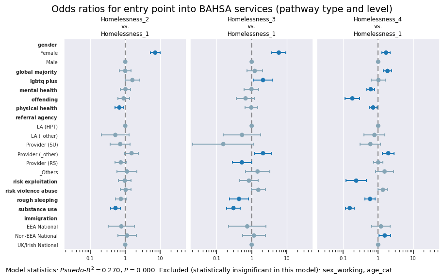

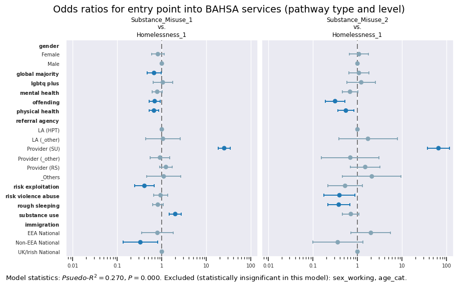

```python
import seaborn.objects as so
import matplotlib.pyplot as plt
import seaborn as sns
import matplotlib


def plot_odds_r(dv_str, dv_ref_cat, iv_ref_cats, results_or_final, x_max=None, wrap=None, replacements={}, theme={}, figsize=(9.5, 6)):
    global figure_major_i, figure_minor_i
    f_i = f"{figure_major_i}.{figure_minor_i}"
    plot_or = results_or_final.dropna()
    ci_lo = plot_or.columns[-2]
    ci_hi = plot_or.columns[-1]

    footer_text = (r"Model statistics: $Psuedo\text{-}R^2=" + f"{results.prsquared:.3f}$, " +
                   r"$P=" + f"{results.llr_pvalue:.3f}$. Excluded (statistically insignificant in this model): " +
                   ", ".join(cols_to_remove) + ".")
    if type(plot_or.index) is pd.MultiIndex:
        # 1. Remove Intercept rows
        plot_or = plot_or.drop(index=plot_or.loc[(slice(None), "(Intercept)"), :].index)
        # 2. Add iv_ref_cat rows with odds_r and both C.I.s == 1.0 for IVs still in the model
        ref_cat_data = {"p": pd.NA, "*": "", "odds_r": 1.0, ci_lo: 1.0, ci_hi: 1.0}
        ref_cat_idx = pd.MultiIndex.from_tuples(product(plot_or.index.levels[0], iv_ref_cats.values()))
        ref_cat_df = pd.DataFrame(data=ref_cat_data, index=ref_cat_idx)
        ref_cat_title_data = {"p": pd.NA, "*": "", "odds_r": pd.NA, ci_lo: pd.NA, ci_hi: pd.NA}
        ref_cat_title_bold = {i: r"$\bf{" + i.replace("_", r"\ ") + "}$" for i in iv_ref_cats.keys()}
        ref_cat_title_idx = pd.MultiIndex.from_tuples(product(plot_or.index.levels[0], iv_ref_cats.keys()))
        ref_cat_title_df = pd.DataFrame(data=ref_cat_title_data, index=ref_cat_title_idx)
        plot_or = pd.concat([plot_or, ref_cat_df, ref_cat_title_df]).sort_index().rename_axis(index=["dv", "iv"]).reset_index()
        # Shorten IVs by separating into groups
        plot_or["iv"] = plot_or["iv"].str.replace("|".join([x + "_" for x in iv_ref_cats.keys()]), "", regex=True)
        plot_or["iv"] = plot_or["iv"].replace(ref_cat_title_bold)
        # Bold binaries
        binaries_bold = {i: r"$\bf{" + i.replace("_", r"\ ") + "}$" for i in binaries}
        plot_or["iv"] = plot_or["iv"].replace(binaries_bold)
        # short_ivs = plot_or.index.levels[1].str.replace("|".join([x + "_" for x in iv_ref_cats.keys()]), "", regex=True)
        # 3. Add title "vs dv_ref_cat"
        # plot_or.index = plot_or.index.set_levels(plot_or.index.levels[0] + "\nvs.\n" + dv_ref_cat, level=0)
        # plot_or.index = plot_or.index + "\nvs.\n" + dv_ref_cat
        plot_or["dv"] = plot_or["dv"] + "\nvs.\n" + dv_ref_cat
    else:
        # 1. Remove Intercept rows
        plot_or = plot_or.drop(index="(Intercept)")
        # 2. Add iv_ref_cat rows with odds_r and both C.I.s == 1.0 for IVs still in the model
        ref_cat_data = {"p": pd.NA, "*": "", "odds_r": 1.0, ci_lo: 1.0, ci_hi: 1.0}
        ref_cat_idx = list(iv_ref_cats.values())
        ref_cat_df = pd.DataFrame(data=ref_cat_data, index=ref_cat_idx)
        ref_cat_title_data = {"p": pd.NA, "*": "", "odds_r": pd.NA, ci_lo: pd.NA, ci_hi: pd.NA}
        ref_cat_title_bold = {i: r"$\bf{" + i.replace("_", r"\ ") + "}$" for i in iv_ref_cats.keys()}
        ref_cat_title_idx = iv_ref_cats.keys()
        ref_cat_title_df = pd.DataFrame(data=ref_cat_title_data, index=ref_cat_title_idx)
        plot_or = pd.concat([plot_or, ref_cat_df, ref_cat_title_df]).sort_index().rename_axis(index="iv").reset_index()
        plot_or["iv"] = plot_or["iv"].str.replace("|".join([x + "_" for x in iv_ref_cats.keys()]), "", regex=True)
        plot_or["iv"] = plot_or["iv"].replace(ref_cat_title_bold)
        binaries_bold = {i: r"$\bf{" + i.replace("_", r"\ ") + "}$" for i in binaries}
        plot_or["iv"] = plot_or["iv"].replace(binaries_bold)

    for pat, repl in replacements.items():
        plot_or["iv"] = plot_or["iv"].str.replace(pat, repl)
    plot_or["*"] = (plot_or["*"] == "*") & plot_or["*"].notna()
    # lines = plot_or[["dv", "iv"]].assign(line_1=1)
    # log_plot_or = pd.concat([plot_or.iloc[:, :-3], np.log(plot_or.iloc[:, -3:])], axis=1)
    fig = plt.figure(figsize=figsize)
    fig.suptitle("Odds ratios for " + dv_str[:1].lower() + dv_str[1:], wrap=True)
    txt = fig.supxlabel(t=footer_text, x=0.01, y=0.01, ha="left", va="bottom", fontsize="small", wrap=True)
    # fig_top, fig_bottom = fig.subfigures(2, 1, height_ratios=[44, 1])
    # fig_top = fig
    # fig_bottom = fig
    if x_max is None:
        max_x_axis_exp = 1.04 * np.log(plot_or[ci_hi].max())
        min_x_axis_exp_mag = 1.04 * abs(np.log(plot_or[ci_lo].min()))
        max_x_axis_exp = np.log(10) if max_x_axis_exp < np.log(10) else max(max_x_axis_exp, min_x_axis_exp_mag)
    else:
        max_x_axis_exp = np.log(x_max)
    x_limits = (np.exp(-max_x_axis_exp), np.exp(max_x_axis_exp))
    palette = sns.color_palette("Paired")
    colours = [palette[1], palette[0]]
    colours[1] = tuple((c * 0.8 for c in colours[1]))
    updated_theme = {"font.size": 9, "xtick.labelsize": "small", "ytick.labelsize": "medium",
                     "axes.titlesize": "medium", "axes.grid.which": "major",
                     "xtick.bottom": True, "xtick.minor.size": 3.5, "xtick.major.size": 7}
    updated_theme.update(theme)
    p = (so.Plot(data=plot_or, y="iv", x="odds_r", xmin=ci_lo, xmax=ci_hi, color="*")
         .label(x="", y="")
         .limit(x=x_limits)
         # .layout(size=(9.5, 6), engine="constrained")
         .theme(updated_theme)
         .scale(color=colours)
         .add(so.Dots(pointsize=6, fillalpha=1.0, artist_kws={"zorder": 2.5}))
         .add(so.Range())
         .add(so.Dash(), x=ci_lo, width=0.2)
         .add(so.Dash(), x=ci_hi, width=0.2)
         )
    if type(results_or_final.index) is pd.MultiIndex:
        p = p.facet("dv", wrap=wrap)
    fig_str = assets_output + f"Figure_{f_i}.svg"
    pl = p.on(fig).plot()
    # txt_bb = txt.get_window_extent(renderer=fig.canvas.get_renderer())
    # fig.get_layout_engine().set(h_pad=(6/72, 0))
    fig.legends.pop(0)
    plt.xscale("log")
    for ax in fig.axes:
        ax.axvline(x=1, color="black", alpha=0.5, linestyle=(0, (5, 3)), zorder=1.01)
        ax.xaxis.grid(True, which="major")
        # ax.xaxis.set_major_formatter(matplotlib.ticker.LogFormatterExponent())
    ax.xaxis.set_major_formatter(matplotlib.ticker.StrMethodFormatter("{x:g}"))
    fig.tight_layout(rect=[0,0,1,1], pad=0.5, h_pad=1)
    fig.savefig(fig_str)
    return fig_str, fig


figure_minor_i = 1
shorter_iv = {"Local authority": "LA", "Service provider": "Provider", "SU pathway, prison wk": "SU", "_other SH": "_other",
              "rough sleeping and SH": "RS", "Housing Options": "HPT", r"uk\ immigration\ status": "immigration"}
theme = {"ytick.labelsize": "small"}
ref_cats_used = {k: v for k, v in ref_cats.items() if k in iv_cols_used and v[-6:] != "_False"}
# Split into two plots
for or_section, i_sub in [(slice(0, 3), "a"), (slice(3, None), "b")]:
    save_fmi = figure_minor_i
    temp_res_or = results_or_final.loc[results_or_final.index.levels[0][or_section]].copy()
    temp_res_or.index = temp_res_or.index.remove_unused_levels()
    figure_minor_i = str(figure_minor_i) + i_sub
    fig_str, fig = plot_odds_r(dv_str, dv.cat.categories[0], ref_cats_used, temp_res_or, replacements=shorter_iv, theme=theme)
    plt.show(block=False)
    figure_minor_i = save_fmi
```

# Route outcomes after 3.08 years

## Prepare DV

```python
import statsmodels.api as sm
from statsmodels.stats.outliers_influence import variance_inflation_factor as sm_vif

# Get DV
dv_str = "Route outcomes after 3.08 years"
dv = dv_dict[dv_str].iloc[:, 0].astype("category")
dv = dv.cat.reorder_categories(['Independent accommodation', 'Insecure outcome', 'Returned to homelessness', 'Died'])
```

## Prepare IVs

```python
cols_to_exclude = ["pway_lvl", "referral_agency"]
X, Xc, iv_df, iv_cols_used, ref_cats, binaries = get_ivs(dv, cols_to_exclude)
```

## Test associations between IVs

```python
import scipy.stats as ss
from itertools import product
# Alpha
alpha = 0.05
iv_df_used = iv_df[iv_cols_used]
iv_df_used = iv_df_used.dropna()
# Ensure relevant variables exclude cases where results are NA
X = X.loc[iv_df_used.index]
Xc = Xc.loc[iv_df_used.index]
dv = dv.loc[iv_df_used.index]
# Test chi squared and Cramer's V for contingency tables
iv_prod = [(iv1, iv2) for iv1, iv2 in product(iv_df_used.columns, repeat=2) if iv1 != iv2]
def chi2(iv1, iv2):
    ct = pd.crosstab(iv_df_used[iv1], iv_df_used[iv2])
    chi2, pvalue, dof, arr = ss.chi2_contingency(ct)
    if pvalue < 0.001: p_sig = "***"
    elif pvalue < 0.01: p_sig = "**"
    elif pvalue < alpha: p_sig = "*"
    else: p_sig = ""
    cr_v = ss.contingency.association(ct, method="cramer")
    return (chi2, pvalue, p_sig, dof, cr_v)
results = (pd.DataFrame([(iv1, iv2) + chi2(iv1, iv2) for iv1, iv2 in iv_prod],
                        columns=["iv1", "iv2", "chi2", "p", "p_sig", "df", "cr_v"]))
results["iv2"] = results["iv2"].str.replace(r"^(.)[^_]*|_(.)[^_]*", r"\1\2", regex=True)
results["disp"] = results["p_sig"] + results["cr_v"].apply("{:,.3f}".format)
pvalues = results.pivot(index="iv1", columns="iv2", values="p").rename_axis("p", axis=1).rename_axis(None)
p_sig = results.pivot(index="iv1", columns="iv2", values="p_sig").rename_axis("*", axis=1).rename_axis(None)
cr_v = results.pivot(index="iv1", columns="iv2", values="cr_v").rename_axis("V", axis=1).rename_axis(None)
disp = pd.concat([cr_v, p_sig], keys=["V", "*"]).swaplevel().sort_index(ascending=[True, False])
```

### Cramer’s V

p values indicated by asterisks: `***` if `p < 0.001`, `**` if `p < 0.01`, `*` if `p < 0.05`

```python
with pd.option_context("display.float_format", "{:,.3f}".format):
    display(disp)
```

|  |  | ac | g | gm | lp | md | mh | o | ph | re | rs | rva | su | sw | uis |
| --- | --- | --- | --- | --- | --- | --- | --- | --- | --- | --- | --- | --- | --- | --- | --- |
| age_cat | V | NaN | 0.117 | 0.067 | 0.075 | 0.040 | 0.061 | 0.003 | 0.212 | 0.018 | 0.012 | 0.038 | 0.149 | 0.002 | 0.082 |
|  | * | NaN | *** | ** | *** |  | ** |  | *** |  |  |  | *** |  | *** |
| gender | V | 0.117 | NaN | 0.058 | 0.165 | 0.037 | 0.126 | 0.182 | 0.075 | 0.130 | 0.046 | 0.358 | 0.073 | 0.288 | 0.072 |
|  | * | *** | NaN |  | *** |  | *** | *** | ** | *** |  | *** | ** | *** | *** |
| global_majority | V | 0.067 | 0.058 | NaN | 0.007 | 0.191 | 0.072 | 0.085 | 0.080 | 0.046 | 0.103 | 0.031 | 0.263 | 0.078 | 0.451 |
|  | * | ** |  | NaN |  | *** | *** | *** | *** | * | *** |  | *** | *** | *** |
| lgbtq_plus | V | 0.075 | 0.165 | 0.007 | NaN | 0.046 | 0.027 | 0.072 | 0.003 | 0.018 | 0.016 | 0.002 | 0.073 | 0.005 | 0.052 |
|  | * | *** | *** |  | NaN | * |  | ** |  |  |  |  | *** |  | * |
| mental_health | V | 0.061 | 0.126 | 0.072 | 0.027 | 0.560 | NaN | 0.080 | 0.112 | 0.089 | 0.110 | 0.077 | 0.194 | 0.103 | 0.101 |
|  | * | ** | *** | *** |  | *** | NaN | *** | *** | *** | *** | *** | *** | *** | *** |
| multiple_disadvantage | V | 0.040 | 0.037 | 0.191 | 0.046 | NaN | 0.560 | 0.373 | 0.137 | 0.157 | 0.236 | 0.258 | 0.679 | 0.126 | 0.201 |
|  | * |  |  | *** | * | NaN | *** | *** | *** | *** | *** | *** | *** | *** | *** |
| offending | V | 0.003 | 0.182 | 0.085 | 0.072 | 0.373 | 0.080 | NaN | 0.034 | 0.017 | 0.147 | 0.002 | 0.188 | 0.063 | 0.131 |
|  | * |  | *** | *** | ** | *** | *** | NaN |  |  | *** |  | *** | ** | *** |
| physical_health | V | 0.212 | 0.075 | 0.080 | 0.003 | 0.137 | 0.112 | 0.034 | NaN | 0.091 | 0.126 | 0.077 | 0.141 | 0.097 | 0.053 |
|  | * | *** | ** | *** |  | *** | *** |  | NaN | *** | *** | *** | *** | *** | * |
| risk_exploitation | V | 0.018 | 0.130 | 0.046 | 0.018 | 0.157 | 0.089 | 0.017 | 0.091 | NaN | 0.001 | 0.228 | 0.136 | 0.151 | 0.069 |
|  | * |  | *** | * |  | *** | *** |  | *** | NaN |  | *** | *** | *** | ** |
| risk_violence_abuse | V | 0.038 | 0.358 | 0.031 | 0.002 | 0.258 | 0.077 | 0.002 | 0.077 | 0.228 | 0.037 | NaN | 0.038 | 0.283 | 0.028 |
|  | * |  | *** |  |  | *** | *** |  | *** | *** |  | NaN |  | *** |  |
| rough_sleeping | V | 0.012 | 0.046 | 0.103 | 0.016 | 0.236 | 0.110 | 0.147 | 0.126 | 0.001 | NaN | 0.037 | 0.238 | 0.081 | 0.060 |
|  | * |  |  | *** |  | *** | *** | *** | *** |  | NaN |  | *** | *** | * |
| sex_working | V | 0.002 | 0.288 | 0.078 | 0.005 | 0.126 | 0.103 | 0.063 | 0.097 | 0.151 | 0.081 | 0.283 | 0.109 | NaN | 0.037 |
|  | * |  | *** | *** |  | *** | *** | ** | *** | *** | *** | *** | *** | NaN |  |
| substance_use | V | 0.149 | 0.073 | 0.263 | 0.073 | 0.679 | 0.194 | 0.188 | 0.141 | 0.136 | 0.238 | 0.038 | NaN | 0.109 | 0.213 |
|  | * | *** | ** | *** | *** | *** | *** | *** | *** | *** | *** |  | NaN | *** | *** |
| uk_immigration_status | V | 0.082 | 0.072 | 0.451 | 0.052 | 0.201 | 0.101 | 0.131 | 0.053 | 0.069 | 0.060 | 0.028 | 0.213 | 0.037 | NaN |
|  | * | *** | *** | *** | * | *** | *** | *** | * | ** | * |  | *** |  | NaN |

### Variance Inflation Factor (VIF)

```python
# Test multicollinearity with VIF
vif_data = pd.DataFrame()
vif_data["Feature"] = Xc.columns
vif_data["VIF"] = [sm_vif(Xc.astype("float").values, i) for i in range(len(Xc.columns))]
vif_data = vif_data.set_index("Feature").sort_values("VIF", ascending=False)
with pd.option_context("display.float_format", "{:,.3f}".format):
    display(vif_data)
```

| Feature | VIF |
| --- | --- |
| (Intercept) | 7.615 |
| multiple_disadvantage | 4.006 |
| substance_use | 2.457 |
| mental_health | 1.801 |
| risk_violence_abuse | 1.421 |
| offending | 1.332 |
| global_majority | 1.316 |
| gender_Female | 1.289 |
| uk_immigration_status_Non-EEA National | 1.287 |
| sex_working | 1.195 |
| physical_health | 1.101 |
| age_cat_34- | 1.099 |
| rough_sleeping | 1.095 |
| risk_exploitation | 1.095 |
| uk_immigration_status_EEA National | 1.025 |
| lgbtq_plus | 1.019 |

So multiple_disadvantage and substance_use are both causing higher variance inflation and are strongly correlated. This makes sense: multiple_disadvantage is defined by the existence of 3+ factors including substance use.

### VIF without multiple_disadvantage

```python
cols_to_remove = ["multiple_disadvantage"]
Xc = Xc[[col for col in Xc.columns if not col.startswith(tuple(cols_to_remove))]]

vif_data = pd.DataFrame()
vif_data["Feature"] = Xc.columns
vif_data["VIF"] = [sm_vif(Xc.astype("float").values, i) for i in range(len(Xc.columns))]
vif_data = vif_data.set_index("Feature").sort_values("VIF", ascending=False)
with pd.option_context("display.float_format", "{:,.3f}".format):
    display(vif_data)
```

| Feature | VIF |
| --- | --- |
| (Intercept) | 7.012 |
| global_majority | 1.316 |
| gender_Female | 1.289 |
| uk_immigration_status_Non-EEA National | 1.286 |
| substance_use | 1.258 |
| risk_violence_abuse | 1.231 |
| sex_working | 1.182 |
| offending | 1.110 |
| physical_health | 1.101 |
| age_cat_34- | 1.098 |
| risk_exploitation | 1.094 |
| mental_health | 1.094 |
| rough_sleeping | 1.093 |
| uk_immigration_status_EEA National | 1.024 |
| lgbtq_plus | 1.019 |

Now all variance inflation is low. Therefore despite some association between variables, model building can proceed.

## Model building

```python
from IPython.display import Markdown

# No need to redefine multinomial_regresssion function

iter = 0
display(Markdown(f"### Iteration {iter}"))
cols_to_remove = []
results, summary, results_or = multinomial_regression(dv, Xc, cols_to_remove)

iter += 1
cols_to_remove.append("lgbtq_plus")
display(Markdown(f"### Iteration {iter}, without: {", ".join(cols_to_remove)}"))
results, summary, results_or = multinomial_regression(dv, Xc, cols_to_remove)

iter += 1
cols_to_remove.append("mental_health")
display(Markdown(f"### Iteration {iter}, without: {", ".join(cols_to_remove)}"))
results, summary, results_or = multinomial_regression(dv, Xc, cols_to_remove)

iter += 1
cols_to_remove.append("global_majority")
display(Markdown(f"### Iteration {iter}, without: {", ".join(cols_to_remove)}"))
results, summary, results_or = multinomial_regression(dv, Xc, cols_to_remove)

iter += 1
cols_to_remove.append("risk_violence_abuse")
display(Markdown(f"### Iteration {iter}, without: {", ".join(cols_to_remove)}"))
results, summary, results_or = multinomial_regression(dv, Xc, cols_to_remove)

assert (cols_to_remove ==
        ['lgbtq_plus', 'mental_health',
        'global_majority', 'risk_violence_abuse'])

# Update iv_cols_used
iv_cols_used = [i for i in iv_cols_used if i not in cols_to_remove]
```

Iteration 0

```
Optimization terminated successfully.
         Current function value: 1.026370
         Iterations 9
```

MNLogit Regression Results

| Dep. Variable: | rt_outcome | No. Observations: | 2195 |
| --- | --- | --- | --- |
| Model: | MNLogit | Df Residuals: | 2150 |
| Method: | MLE | Df Model: | 42 |
| Date: | Mon, 01 Jun 2026 | Pseudo R-squ.: | 0.1152 |
| Time: | 21:49:03 | Log-Likelihood: | -2252.9 |
| converged: | True | LL-Null: | -2546.1 |
| Covariance Type: | nonrobust | LLR p-value: | 4.317e-97 |

| rt_outcome=Insecure outcome | coef | std err | z | P>\|z\| | [0.025 | 0.975] |
| --- | --- | --- | --- | --- | --- | --- |
| (Intercept) | -0.8878 | 0.145 | -6.121 | 0.000 | -1.172 | -0.603 |
| gender_Female | -0.2208 | 0.142 | -1.554 | 0.120 | -0.499 | 0.058 |
| global_majority | -0.0368 | 0.154 | -0.239 | 0.811 | -0.339 | 0.265 |
| uk_immigration_status_Non-EEA National | -0.4661 | 0.237 | -1.969 | 0.049 | -0.930 | -0.002 |
| uk_immigration_status_EEA National | 0.1936 | 0.345 | 0.561 | 0.575 | -0.483 | 0.870 |
| age_cat_34- | 0.2904 | 0.125 | 2.327 | 0.020 | 0.046 | 0.535 |
| lgbtq_plus | 0.1149 | 0.239 | 0.481 | 0.630 | -0.353 | 0.583 |
| offending | 1.1711 | 0.183 | 6.382 | 0.000 | 0.811 | 1.531 |
| physical_health | 0.3154 | 0.125 | 2.521 | 0.012 | 0.070 | 0.561 |
| mental_health | 0.1162 | 0.128 | 0.905 | 0.365 | -0.135 | 0.368 |
| substance_use | 1.1744 | 0.126 | 9.309 | 0.000 | 0.927 | 1.422 |
| rough_sleeping | 0.5422 | 0.168 | 3.236 | 0.001 | 0.214 | 0.871 |
| sex_working | 1.6998 | 0.767 | 2.216 | 0.027 | 0.196 | 3.203 |
| risk_violence_abuse | -0.0894 | 0.182 | -0.492 | 0.622 | -0.445 | 0.266 |
| risk_exploitation | 0.5727 | 0.233 | 2.454 | 0.014 | 0.115 | 1.030 |
| rt_outcome=Returned to homelessness | coef | std err | z | P>\|z\| | [0.025 | 0.975] |
| (Intercept) | -1.1742 | 0.156 | -7.525 | 0.000 | -1.480 | -0.868 |
| gender_Female | -0.3603 | 0.156 | -2.317 | 0.021 | -0.665 | -0.056 |
| global_majority | -0.1632 | 0.169 | -0.967 | 0.334 | -0.494 | 0.168 |
| uk_immigration_status_Non-EEA National | -0.7156 | 0.286 | -2.505 | 0.012 | -1.275 | -0.156 |
| uk_immigration_status_EEA National | 0.3425 | 0.364 | 0.942 | 0.346 | -0.370 | 1.055 |
| age_cat_34- | 0.1563 | 0.133 | 1.173 | 0.241 | -0.105 | 0.417 |
| lgbtq_plus | 0.0741 | 0.263 | 0.281 | 0.779 | -0.442 | 0.591 |
| offending | 1.4410 | 0.185 | 7.771 | 0.000 | 1.078 | 1.804 |
| physical_health | 0.1494 | 0.133 | 1.127 | 0.260 | -0.110 | 0.409 |
| mental_health | -0.1487 | 0.136 | -1.096 | 0.273 | -0.415 | 0.117 |
| substance_use | 1.6500 | 0.138 | 11.984 | 0.000 | 1.380 | 1.920 |
| rough_sleeping | 1.1933 | 0.165 | 7.227 | 0.000 | 0.870 | 1.517 |
| sex_working | 1.9261 | 0.771 | 2.497 | 0.013 | 0.414 | 3.438 |
| risk_violence_abuse | 0.0809 | 0.191 | 0.424 | 0.671 | -0.293 | 0.455 |
| risk_exploitation | 0.4072 | 0.246 | 1.657 | 0.098 | -0.074 | 0.889 |
| rt_outcome=Died | coef | std err | z | P>\|z\| | [0.025 | 0.975] |
| (Intercept) | -4.4503 | 0.618 | -7.196 | 0.000 | -5.663 | -3.238 |
| gender_Female | -0.5063 | 0.514 | -0.985 | 0.325 | -1.514 | 0.501 |
| global_majority | -0.0916 | 0.519 | -0.177 | 0.860 | -1.108 | 0.925 |
| uk_immigration_status_Non-EEA National | 0.2867 | 0.710 | 0.404 | 0.686 | -1.105 | 1.678 |
| uk_immigration_status_EEA National | 0.9898 | 0.819 | 1.209 | 0.227 | -0.615 | 2.594 |
| age_cat_34- | -0.4596 | 0.454 | -1.013 | 0.311 | -1.349 | 0.429 |
| lgbtq_plus | 0.2863 | 0.786 | 0.364 | 0.716 | -1.255 | 1.827 |
| offending | 0.1172 | 0.569 | 0.206 | 0.837 | -0.998 | 1.232 |
| physical_health | 0.5944 | 0.361 | 1.646 | 0.100 | -0.113 | 1.302 |
| mental_health | -0.3476 | 0.380 | -0.915 | 0.360 | -1.092 | 0.397 |
| substance_use | 2.8009 | 0.560 | 5.004 | 0.000 | 1.704 | 3.898 |
| rough_sleeping | -0.2023 | 0.513 | -0.394 | 0.693 | -1.208 | 0.803 |
| sex_working | 3.3466 | 1.190 | 2.813 | 0.005 | 1.015 | 5.678 |
| risk_violence_abuse | -0.8483 | 0.736 | -1.153 | 0.249 | -2.290 | 0.594 |
| risk_exploitation | -0.4156 | 0.777 | -0.535 | 0.593 | -1.937 | 1.106 |

|  | Odds Ratios | p | * | odds_r | [0.025 | 0.975] |
| --- | --- | --- | --- | --- | --- | --- |
| lgbtq_plus | Returned to homelessness | 0.779 |  | 1.077 | 0.643 | 1.805 |
|  | Insecure outcome | 0.630 |  | 1.122 | 0.703 | 1.791 |
|  | Died | 0.716 |  | 1.331 | 0.285 | 6.217 |
| global_majority | Insecure outcome | 0.811 |  | 0.964 | 0.712 | 1.304 |
|  | Died | 0.860 |  | 0.912 | 0.330 | 2.521 |
|  | Returned to homelessness | 0.334 |  | 0.849 | 0.610 | 1.182 |
| mental_health | Died | 0.360 |  | 0.706 | 0.336 | 1.487 |
|  | Returned to homelessness | 0.273 |  | 0.862 | 0.661 | 1.124 |
|  | Insecure outcome | 0.365 |  | 1.123 | 0.873 | 1.445 |
| risk_violence_abuse | Died | 0.249 |  | 0.428 | 0.101 | 1.811 |
|  | Returned to homelessness | 0.671 |  | 1.084 | 0.746 | 1.575 |
|  | Insecure outcome | 0.622 |  | 0.914 | 0.641 | 1.305 |
| uk_immigration_status_EEA National | Died | 0.227 |  | 2.691 | 0.541 | 13.387 |
|  | Insecure outcome | 0.575 |  | 1.214 | 0.617 | 2.388 |
|  | Returned to homelessness | 0.346 |  | 1.409 | 0.691 | 2.873 |
| gender_Female | Died | 0.325 |  | 0.603 | 0.220 | 1.651 |
|  | Insecure outcome | 0.120 |  | 0.802 | 0.607 | 1.059 |
|  | Returned to homelessness | 0.021 | * | 0.697 | 0.514 | 0.946 |
| age_cat_34- | Returned to homelessness | 0.241 |  | 1.169 | 0.901 | 1.518 |
|  | Died | 0.311 |  | 0.632 | 0.260 | 1.536 |
|  | Insecure outcome | 0.020 | * | 1.337 | 1.047 | 1.708 |
| risk_exploitation | Returned to homelessness | 0.098 |  | 1.503 | 0.928 | 2.432 |
|  | Died | 0.593 |  | 0.660 | 0.144 | 3.023 |
|  | Insecure outcome | 0.014 | * | 1.773 | 1.122 | 2.801 |
| uk_immigration_status_Non-EEA National | Died | 0.686 |  | 1.332 | 0.331 | 5.356 |
|  | Insecure outcome | 0.049 | * | 0.627 | 0.395 | 0.998 |
|  | Returned to homelessness | 0.012 | * | 0.489 | 0.279 | 0.856 |
| physical_health | Returned to homelessness | 0.260 |  | 1.161 | 0.895 | 1.506 |
|  | Died | 0.100 |  | 1.812 | 0.893 | 3.676 |
|  | Insecure outcome | 0.012 | * | 1.371 | 1.073 | 1.752 |
| sex_working | Returned to homelessness | 0.013 | * | 6.862 | 1.513 | 31.122 |
|  | Insecure outcome | 0.027 | * | 5.473 | 1.217 | 24.610 |
|  | Died | 0.005 | * | 28.405 | 2.759 | 292.489 |
| rough_sleeping | Died | 0.693 |  | 0.817 | 0.299 | 2.233 |
|  | Returned to homelessness | 0.000 | * | 3.298 | 2.386 | 4.558 |
|  | Insecure outcome | 0.001 | * | 1.720 | 1.238 | 2.388 |
| (Intercept) | Insecure outcome | 0.000 | * | 0.412 | 0.310 | 0.547 |
|  | Died | 0.000 | * | 0.012 | 0.003 | 0.039 |
|  | Returned to homelessness | 0.000 | * | 0.309 | 0.228 | 0.420 |
| offending | Died | 0.837 |  | 1.124 | 0.369 | 3.429 |
|  | Insecure outcome | 0.000 | * | 3.226 | 2.251 | 4.622 |
|  | Returned to homelessness | 0.000 | * | 4.225 | 2.937 | 6.076 |
| substance_use | Returned to homelessness | 0.000 | * | 5.207 | 3.975 | 6.820 |
|  | Died | 0.000 | * | 16.459 | 5.495 | 49.297 |
|  | Insecure outcome | 0.000 | * | 3.236 | 2.527 | 4.144 |

```
Psuedo R^2: 0.11517221431468116
--------------------------------------------------
```

Iteration 1, without: lgbtq_plus

```
Optimization terminated successfully.
         Current function value: 1.026440
         Iterations 9
```

MNLogit Regression Results

| Dep. Variable: | rt_outcome | No. Observations: | 2195 |
| --- | --- | --- | --- |
| Model: | MNLogit | Df Residuals: | 2153 |
| Method: | MLE | Df Model: | 39 |
| Date: | Mon, 01 Jun 2026 | Pseudo R-squ.: | 0.1151 |
| Time: | 21:49:03 | Log-Likelihood: | -2253.0 |
| converged: | True | LL-Null: | -2546.1 |
| Covariance Type: | nonrobust | LLR p-value: | 8.660e-99 |

| rt_outcome=Insecure outcome | coef | std err | z | P>\|z\| | [0.025 | 0.975] |
| --- | --- | --- | --- | --- | --- | --- |
| (Intercept) | -0.8817 | 0.144 | -6.103 | 0.000 | -1.165 | -0.599 |
| gender_Female | -0.2189 | 0.142 | -1.542 | 0.123 | -0.497 | 0.059 |
| global_majority | -0.0390 | 0.154 | -0.253 | 0.800 | -0.341 | 0.263 |
| uk_immigration_status_Non-EEA National | -0.4624 | 0.237 | -1.954 | 0.051 | -0.926 | 0.001 |
| uk_immigration_status_EEA National | 0.1975 | 0.345 | 0.573 | 0.567 | -0.478 | 0.874 |
| age_cat_34- | 0.2928 | 0.125 | 2.348 | 0.019 | 0.048 | 0.537 |
| offending | 1.1681 | 0.183 | 6.370 | 0.000 | 0.809 | 1.527 |
| physical_health | 0.3160 | 0.125 | 2.526 | 0.012 | 0.071 | 0.561 |
| mental_health | 0.1190 | 0.128 | 0.928 | 0.353 | -0.132 | 0.370 |
| substance_use | 1.1704 | 0.126 | 9.300 | 0.000 | 0.924 | 1.417 |
| rough_sleeping | 0.5422 | 0.168 | 3.236 | 0.001 | 0.214 | 0.871 |
| sex_working | 1.6928 | 0.767 | 2.208 | 0.027 | 0.190 | 3.195 |
| risk_violence_abuse | -0.0885 | 0.182 | -0.487 | 0.626 | -0.444 | 0.267 |
| risk_exploitation | 0.5717 | 0.233 | 2.452 | 0.014 | 0.115 | 1.029 |
| rt_outcome=Returned to homelessness | coef | std err | z | P>\|z\| | [0.025 | 0.975] |
| (Intercept) | -1.1699 | 0.155 | -7.533 | 0.000 | -1.474 | -0.865 |
| gender_Female | -0.3595 | 0.155 | -2.313 | 0.021 | -0.664 | -0.055 |
| global_majority | -0.1650 | 0.169 | -0.978 | 0.328 | -0.496 | 0.166 |
| uk_immigration_status_Non-EEA National | -0.7129 | 0.286 | -2.496 | 0.013 | -1.273 | -0.153 |
| uk_immigration_status_EEA National | 0.3440 | 0.363 | 0.947 | 0.344 | -0.368 | 1.056 |
| age_cat_34- | 0.1572 | 0.133 | 1.182 | 0.237 | -0.103 | 0.418 |
| offending | 1.4391 | 0.185 | 7.767 | 0.000 | 1.076 | 1.802 |
| physical_health | 0.1496 | 0.133 | 1.128 | 0.259 | -0.110 | 0.409 |
| mental_health | -0.1467 | 0.136 | -1.082 | 0.279 | -0.412 | 0.119 |
| substance_use | 1.6471 | 0.137 | 11.990 | 0.000 | 1.378 | 1.916 |
| rough_sleeping | 1.1932 | 0.165 | 7.227 | 0.000 | 0.870 | 1.517 |
| sex_working | 1.9195 | 0.771 | 2.490 | 0.013 | 0.408 | 3.431 |
| risk_violence_abuse | 0.0827 | 0.191 | 0.434 | 0.664 | -0.291 | 0.456 |
| risk_exploitation | 0.4053 | 0.246 | 1.650 | 0.099 | -0.076 | 0.887 |
| rt_outcome=Died | coef | std err | z | P>\|z\| | [0.025 | 0.975] |
| (Intercept) | -4.4383 | 0.619 | -7.176 | 0.000 | -5.651 | -3.226 |
| gender_Female | -0.5017 | 0.514 | -0.976 | 0.329 | -1.509 | 0.505 |
| global_majority | -0.0966 | 0.518 | -0.186 | 0.852 | -1.112 | 0.919 |
| uk_immigration_status_Non-EEA National | 0.2864 | 0.709 | 0.404 | 0.686 | -1.104 | 1.677 |
| uk_immigration_status_EEA National | 1.0216 | 0.809 | 1.263 | 0.206 | -0.563 | 2.607 |
| age_cat_34- | -0.4404 | 0.448 | -0.984 | 0.325 | -1.318 | 0.437 |
| offending | 0.1102 | 0.569 | 0.194 | 0.846 | -1.004 | 1.225 |
| physical_health | 0.5992 | 0.361 | 1.661 | 0.097 | -0.108 | 1.306 |
| mental_health | -0.3429 | 0.380 | -0.903 | 0.366 | -1.087 | 0.401 |
| substance_use | 2.7923 | 0.559 | 4.992 | 0.000 | 1.696 | 3.889 |
| rough_sleeping | -0.2027 | 0.513 | -0.395 | 0.693 | -1.208 | 0.803 |
| sex_working | 3.3361 | 1.189 | 2.805 | 0.005 | 1.005 | 5.667 |
| risk_violence_abuse | -0.8550 | 0.736 | -1.162 | 0.245 | -2.298 | 0.588 |
| risk_exploitation | -0.4115 | 0.776 | -0.530 | 0.596 | -1.932 | 1.109 |

Variables removed: ['lgbtq_plus']

|  |  | p | * | odds_r | [0.025 | 0.975] | prev_coef | coef | diff_pct |
| --- | --- | --- | --- | --- | --- | --- | --- | --- | --- |
| global_majority | Insecure outcome | 0.800 |  | 0.962 | 0.711 | 1.301 | -0.037 | -0.039 | 5.900 |
|  | Returned to homelessness | 0.328 |  | 0.848 | 0.609 | 1.180 | -0.163 | -0.165 | 1.100 |
|  | Died | 0.852 |  | 0.908 | 0.329 | 2.507 | -0.092 | -0.097 | 5.400 |
| mental_health | Returned to homelessness | 0.279 |  | 0.864 | 0.662 | 1.126 | -0.149 | -0.147 | -1.400 |
|  | Died | 0.366 |  | 0.710 | 0.337 | 1.494 | -0.348 | -0.343 | -1.300 |
|  | Insecure outcome | 0.353 |  | 1.126 | 0.876 | 1.448 | 0.116 | 0.119 | 2.400 |
| risk_violence_abuse | Returned to homelessness | 0.664 |  | 1.086 | 0.748 | 1.578 | 0.081 | 0.083 | 2.200 |
|  | Insecure outcome | 0.626 |  | 0.915 | 0.641 | 1.307 | -0.089 | -0.088 | -1.100 |
|  | Died | 0.245 |  | 0.425 | 0.100 | 1.800 | -0.848 | -0.855 | 0.800 |
| uk_immigration_status_EEA National | Returned to homelessness | 0.344 |  | 1.411 | 0.692 | 2.875 | 0.343 | 0.344 | 0.400 |
|  | Died | 0.206 |  | 2.778 | 0.569 | 13.552 | 0.990 | 1.022 | 3.200 |
|  | Insecure outcome | 0.567 |  | 1.218 | 0.620 | 2.395 | 0.194 | 0.198 | 2.000 |
| gender_Female | Insecure outcome | 0.123 |  | 0.803 | 0.608 | 1.061 | -0.221 | -0.219 | -0.800 |
|  | Returned to homelessness | 0.021 | * | 0.698 | 0.515 | 0.947 | -0.360 | -0.360 | -0.200 |
|  | Died | 0.329 |  | 0.606 | 0.221 | 1.658 | -0.506 | -0.502 | -0.900 |
| age_cat_34- | Died | 0.325 |  | 0.644 | 0.268 | 1.548 | -0.460 | -0.440 | -4.200 |
|  | Insecure outcome | 0.019 | * | 1.340 | 1.050 | 1.711 | 0.290 | 0.293 | 0.800 |
|  | Returned to homelessness | 0.237 |  | 1.170 | 0.902 | 1.519 | 0.156 | 0.157 | 0.600 |
| risk_exploitation | Died | 0.596 |  | 0.663 | 0.145 | 3.033 | -0.416 | -0.411 | -1.000 |
|  | Insecure outcome | 0.014 | * | 1.771 | 1.121 | 2.798 | 0.573 | 0.572 | -0.200 |
|  | Returned to homelessness | 0.099 |  | 1.500 | 0.927 | 2.427 | 0.407 | 0.405 | -0.500 |
| uk_immigration_status_Non-EEA National | Returned to homelessness | 0.013 | * | 0.490 | 0.280 | 0.858 | -0.716 | -0.713 | -0.400 |
|  | Died | 0.686 |  | 1.332 | 0.332 | 5.349 | 0.287 | 0.286 | -0.100 |
|  | Insecure outcome | 0.051 |  | 0.630 | 0.396 | 1.001 | -0.466 | -0.462 | -0.800 |
| physical_health | Died | 0.097 |  | 1.821 | 0.898 | 3.693 | 0.594 | 0.599 | 0.800 |
|  | Returned to homelessness | 0.259 |  | 1.161 | 0.896 | 1.506 | 0.149 | 0.150 | 0.100 |
|  | Insecure outcome | 0.012 | * | 1.372 | 1.073 | 1.753 | 0.315 | 0.316 | 0.200 |
| sex_working | Returned to homelessness | 0.013 | * | 6.818 | 1.504 | 30.897 | 1.926 | 1.920 | -0.300 |
|  | Insecure outcome | 0.027 | * | 5.435 | 1.209 | 24.420 | 1.700 | 1.693 | -0.400 |
|  | Died | 0.005 | * | 28.110 | 2.732 | 289.246 | 3.347 | 3.336 | -0.300 |
| rough_sleeping | Returned to homelessness | 0.000 | * | 3.298 | 2.386 | 4.558 | 1.193 | 1.193 | -0.000 |
|  | Insecure outcome | 0.001 | * | 1.720 | 1.238 | 2.388 | 0.542 | 0.542 | -0.000 |
|  | Died | 0.693 |  | 0.817 | 0.299 | 2.232 | -0.202 | -0.203 | 0.200 |
| (Intercept) | Died | 0.000 | * | 0.012 | 0.004 | 0.040 | -4.450 | -4.438 | -0.300 |
|  | Returned to homelessness | 0.000 | * | 0.310 | 0.229 | 0.421 | -1.174 | -1.170 | -0.400 |
|  | Insecure outcome | 0.000 | * | 0.414 | 0.312 | 0.550 | -0.888 | -0.882 | -0.700 |
| offending | Returned to homelessness | 0.000 | * | 4.217 | 2.933 | 6.064 | 1.441 | 1.439 | -0.100 |
|  | Died | 0.846 |  | 1.116 | 0.366 | 3.403 | 0.117 | 0.110 | -6.000 |
|  | Insecure outcome | 0.000 | * | 3.216 | 2.245 | 4.606 | 1.171 | 1.168 | -0.300 |
| substance_use | Returned to homelessness | 0.000 | * | 5.192 | 3.966 | 6.796 | 1.650 | 1.647 | -0.200 |
|  | Insecure outcome | 0.000 | * | 3.223 | 2.519 | 4.125 | 1.174 | 1.170 | -0.300 |
|  | Died | 0.000 | * | 16.318 | 5.451 | 48.846 | 2.801 | 2.792 | -0.300 |

```
Psuedo R^2: 0.11511215147736642
--------------------------------------------------
```

Iteration 2, without: lgbtq_plus, mental_health

```
Optimization terminated successfully.
         Current function value: 1.027686
         Iterations 9
```

MNLogit Regression Results

| Dep. Variable: | rt_outcome | No. Observations: | 2195 |
| --- | --- | --- | --- |
| Model: | MNLogit | Df Residuals: | 2156 |
| Method: | MLE | Df Model: | 36 |
| Date: | Mon, 01 Jun 2026 | Pseudo R-squ.: | 0.1140 |
| Time: | 21:49:04 | Log-Likelihood: | -2255.8 |
| converged: | True | LL-Null: | -2546.1 |
| Covariance Type: | nonrobust | LLR p-value: | 1.760e-99 |

| rt_outcome=Insecure outcome | coef | std err | z | P>\|z\| | [0.025 | 0.975] |
| --- | --- | --- | --- | --- | --- | --- |
| (Intercept) | -0.8229 | 0.130 | -6.344 | 0.000 | -1.077 | -0.569 |
| gender_Female | -0.2045 | 0.141 | -1.451 | 0.147 | -0.481 | 0.072 |
| global_majority | -0.0376 | 0.154 | -0.244 | 0.807 | -0.339 | 0.264 |
| uk_immigration_status_Non-EEA National | -0.4691 | 0.236 | -1.986 | 0.047 | -0.932 | -0.006 |
| uk_immigration_status_EEA National | 0.1780 | 0.345 | 0.516 | 0.606 | -0.498 | 0.854 |
| age_cat_34- | 0.3029 | 0.124 | 2.440 | 0.015 | 0.060 | 0.546 |
| offending | 1.1745 | 0.183 | 6.410 | 0.000 | 0.815 | 1.534 |
| physical_health | 0.3254 | 0.125 | 2.613 | 0.009 | 0.081 | 0.570 |
| substance_use | 1.1890 | 0.124 | 9.559 | 0.000 | 0.945 | 1.433 |
| rough_sleeping | 0.5500 | 0.167 | 3.286 | 0.001 | 0.222 | 0.878 |
| sex_working | 1.7003 | 0.767 | 2.217 | 0.027 | 0.197 | 3.203 |
| risk_violence_abuse | -0.0872 | 0.182 | -0.480 | 0.631 | -0.443 | 0.269 |
| risk_exploitation | 0.5789 | 0.233 | 2.483 | 0.013 | 0.122 | 1.036 |
| rt_outcome=Returned to homelessness | coef | std err | z | P>\|z\| | [0.025 | 0.975] |
| (Intercept) | -1.2357 | 0.143 | -8.652 | 0.000 | -1.516 | -0.956 |
| gender_Female | -0.3746 | 0.154 | -2.428 | 0.015 | -0.677 | -0.072 |
| global_majority | -0.1694 | 0.169 | -1.004 | 0.315 | -0.500 | 0.161 |
| uk_immigration_status_Non-EEA National | -0.7032 | 0.286 | -2.462 | 0.014 | -1.263 | -0.143 |
| uk_immigration_status_EEA National | 0.3701 | 0.362 | 1.022 | 0.307 | -0.340 | 1.080 |
| age_cat_34- | 0.1428 | 0.132 | 1.080 | 0.280 | -0.116 | 0.402 |
| offending | 1.4313 | 0.185 | 7.733 | 0.000 | 1.068 | 1.794 |
| physical_health | 0.1377 | 0.132 | 1.044 | 0.297 | -0.121 | 0.396 |
| substance_use | 1.6208 | 0.135 | 11.988 | 0.000 | 1.356 | 1.886 |
| rough_sleeping | 1.1840 | 0.165 | 7.177 | 0.000 | 0.861 | 1.507 |
| sex_working | 1.9070 | 0.771 | 2.475 | 0.013 | 0.397 | 3.417 |
| risk_violence_abuse | 0.0790 | 0.191 | 0.414 | 0.679 | -0.295 | 0.452 |
| risk_exploitation | 0.3996 | 0.245 | 1.629 | 0.103 | -0.081 | 0.880 |
| rt_outcome=Died | coef | std err | z | P>\|z\| | [0.025 | 0.975] |
| (Intercept) | -4.6009 | 0.597 | -7.707 | 0.000 | -5.771 | -3.431 |
| gender_Female | -0.5321 | 0.511 | -1.040 | 0.298 | -1.535 | 0.470 |
| global_majority | -0.1060 | 0.519 | -0.204 | 0.838 | -1.123 | 0.911 |
| uk_immigration_status_Non-EEA National | 0.3230 | 0.709 | 0.455 | 0.649 | -1.067 | 1.713 |
| uk_immigration_status_EEA National | 1.0939 | 0.804 | 1.361 | 0.174 | -0.481 | 2.669 |
| age_cat_34- | -0.4801 | 0.445 | -1.079 | 0.280 | -1.352 | 0.392 |
| offending | 0.0893 | 0.568 | 0.157 | 0.875 | -1.024 | 1.202 |
| physical_health | 0.5864 | 0.360 | 1.629 | 0.103 | -0.119 | 1.292 |
| substance_use | 2.7452 | 0.557 | 4.932 | 0.000 | 1.654 | 3.836 |
| rough_sleeping | -0.2317 | 0.512 | -0.453 | 0.651 | -1.235 | 0.772 |
| sex_working | 3.2796 | 1.187 | 2.764 | 0.006 | 0.954 | 5.605 |
| risk_violence_abuse | -0.8795 | 0.733 | -1.201 | 0.230 | -2.315 | 0.556 |
| risk_exploitation | -0.4190 | 0.776 | -0.540 | 0.589 | -1.939 | 1.101 |

Variables removed: ['lgbtq_plus', 'mental_health']

|  |  | p | * | odds_r | [0.025 | 0.975] | prev_coef | coef | diff_pct |
| --- | --- | --- | --- | --- | --- | --- | --- | --- | --- |
| global_majority | Returned to homelessness | 0.315 |  | 0.844 | 0.607 | 1.175 | -0.165 | -0.169 | 2.700 |
|  | Insecure outcome | 0.807 |  | 0.963 | 0.712 | 1.303 | -0.039 | -0.038 | -3.800 |
|  | Died | 0.838 |  | 0.899 | 0.325 | 2.487 | -0.097 | -0.106 | 9.700 |
| risk_violence_abuse | Insecure outcome | 0.631 |  | 0.916 | 0.642 | 1.308 | -0.088 | -0.087 | -1.400 |
|  | Returned to homelessness | 0.679 |  | 1.082 | 0.745 | 1.572 | 0.083 | 0.079 | -4.500 |
|  | Died | 0.230 |  | 0.415 | 0.099 | 1.744 | -0.855 | -0.879 | 2.900 |
| uk_immigration_status_EEA National | Returned to homelessness | 0.307 |  | 1.448 | 0.712 | 2.944 | 0.344 | 0.370 | 7.600 |
|  | Died | 0.174 |  | 2.986 | 0.618 | 14.427 | 1.022 | 1.094 | 7.100 |
|  | Insecure outcome | 0.606 |  | 1.195 | 0.608 | 2.348 | 0.198 | 0.178 | -9.900 |
| gender_Female | Insecure outcome | 0.147 |  | 0.815 | 0.618 | 1.074 | -0.219 | -0.205 | -6.600 |
|  | Died | 0.298 |  | 0.587 | 0.216 | 1.600 | -0.502 | -0.532 | 6.100 |
|  | Returned to homelessness | 0.015 | * | 0.688 | 0.508 | 0.930 | -0.360 | -0.375 | 4.200 |
| age_cat_34- | Died | 0.280 |  | 0.619 | 0.259 | 1.480 | -0.440 | -0.480 | 9.000 |
|  | Insecure outcome | 0.015 | * | 1.354 | 1.061 | 1.727 | 0.293 | 0.303 | 3.500 |
|  | Returned to homelessness | 0.280 |  | 1.154 | 0.890 | 1.495 | 0.157 | 0.143 | -9.100 |
| uk_immigration_status_Non-EEA National | Died | 0.649 |  | 1.381 | 0.344 | 5.546 | 0.286 | 0.323 | 12.800 |
|  | Insecure outcome | 0.047 | * | 0.626 | 0.394 | 0.994 | -0.462 | -0.469 | 1.500 |
|  | Returned to homelessness | 0.014 | * | 0.495 | 0.283 | 0.866 | -0.713 | -0.703 | -1.400 |
| risk_exploitation | Returned to homelessness | 0.103 |  | 1.491 | 0.922 | 2.412 | 0.405 | 0.400 | -1.400 |
|  | Died | 0.589 |  | 0.658 | 0.144 | 3.007 | -0.411 | -0.419 | 1.800 |
|  | Insecure outcome | 0.013 | * | 1.784 | 1.130 | 2.818 | 0.572 | 0.579 | 1.300 |
| physical_health | Returned to homelessness | 0.297 |  | 1.148 | 0.886 | 1.486 | 0.150 | 0.138 | -7.900 |
|  | Died | 0.103 |  | 1.798 | 0.888 | 3.641 | 0.599 | 0.586 | -2.100 |
|  | Insecure outcome | 0.009 | * | 1.385 | 1.085 | 1.768 | 0.316 | 0.325 | 3.000 |
| sex_working | Returned to homelessness | 0.013 | * | 6.733 | 1.487 | 30.482 | 1.920 | 1.907 | -0.700 |
|  | Insecure outcome | 0.027 | * | 5.476 | 1.218 | 24.610 | 1.693 | 1.700 | 0.400 |
|  | Died | 0.006 | * | 26.565 | 2.596 | 271.846 | 3.336 | 3.280 | -1.700 |
| rough_sleeping | Returned to homelessness | 0.000 | * | 3.267 | 2.365 | 4.514 | 1.193 | 1.184 | -0.800 |
|  | Insecure outcome | 0.001 | * | 1.733 | 1.249 | 2.406 | 0.542 | 0.550 | 1.400 |
|  | Died | 0.651 |  | 0.793 | 0.291 | 2.163 | -0.203 | -0.232 | 14.300 |
| offending | Died | 0.875 |  | 1.093 | 0.359 | 3.328 | 0.110 | 0.089 | -18.900 |
|  | Returned to homelessness | 0.000 | * | 4.184 | 2.911 | 6.014 | 1.439 | 1.431 | -0.500 |
|  | Insecure outcome | 0.000 | * | 3.236 | 2.260 | 4.635 | 1.168 | 1.174 | 0.600 |
| (Intercept) | Died | 0.000 | * | 0.010 | 0.003 | 0.032 | -4.438 | -4.601 | 3.700 |
|  | Returned to homelessness | 0.000 | * | 0.291 | 0.220 | 0.385 | -1.170 | -1.236 | 5.600 |
|  | Insecure outcome | 0.000 | * | 0.439 | 0.341 | 0.566 | -0.882 | -0.823 | -6.700 |
| substance_use | Returned to homelessness | 0.000 | * | 5.057 | 3.880 | 6.592 | 1.647 | 1.621 | -1.600 |
|  | Died | 0.000 | * | 15.568 | 5.230 | 46.342 | 2.792 | 2.745 | -1.700 |
|  | Insecure outcome | 0.000 | * | 3.284 | 2.573 | 4.191 | 1.170 | 1.189 | 1.600 |

```
Psuedo R^2: 0.11403780378651862
--------------------------------------------------
```

Iteration 3, without: lgbtq_plus, mental_health, global_majority

```
Optimization terminated successfully.
         Current function value: 1.027949
         Iterations 9
```

MNLogit Regression Results

| Dep. Variable: | rt_outcome | No. Observations: | 2195 |
| --- | --- | --- | --- |
| Model: | MNLogit | Df Residuals: | 2159 |
| Method: | MLE | Df Model: | 33 |
| Date: | Mon, 01 Jun 2026 | Pseudo R-squ.: | 0.1138 |
| Time: | 21:49:05 | Log-Likelihood: | -2256.3 |
| converged: | True | LL-Null: | -2546.1 |
| Covariance Type: | nonrobust | LLR p-value: | 4.183e-101 |

| rt_outcome=Insecure outcome | coef | std err | z | P>\|z\| | [0.025 | 0.975] |
| --- | --- | --- | --- | --- | --- | --- |
| (Intercept) | -0.8325 | 0.123 | -6.770 | 0.000 | -1.073 | -0.591 |
| gender_Female | -0.2011 | 0.141 | -1.429 | 0.153 | -0.477 | 0.075 |
| uk_immigration_status_Non-EEA National | -0.4956 | 0.213 | -2.329 | 0.020 | -0.913 | -0.079 |
| uk_immigration_status_EEA National | 0.1658 | 0.343 | 0.483 | 0.629 | -0.507 | 0.838 |
| age_cat_34- | 0.3019 | 0.124 | 2.432 | 0.015 | 0.059 | 0.545 |
| offending | 1.1744 | 0.183 | 6.409 | 0.000 | 0.815 | 1.534 |
| physical_health | 0.3276 | 0.124 | 2.632 | 0.008 | 0.084 | 0.572 |
| substance_use | 1.1932 | 0.123 | 9.711 | 0.000 | 0.952 | 1.434 |
| rough_sleeping | 0.5495 | 0.167 | 3.285 | 0.001 | 0.222 | 0.877 |
| sex_working | 1.7119 | 0.767 | 2.233 | 0.026 | 0.209 | 3.215 |
| risk_violence_abuse | -0.0882 | 0.182 | -0.486 | 0.627 | -0.444 | 0.268 |
| risk_exploitation | 0.5763 | 0.233 | 2.472 | 0.013 | 0.119 | 1.033 |
| rt_outcome=Returned to homelessness | coef | std err | z | P>\|z\| | [0.025 | 0.975] |
| (Intercept) | -1.2803 | 0.136 | -9.407 | 0.000 | -1.547 | -1.014 |
| gender_Female | -0.3682 | 0.154 | -2.389 | 0.017 | -0.670 | -0.066 |
| uk_immigration_status_Non-EEA National | -0.8134 | 0.263 | -3.092 | 0.002 | -1.329 | -0.298 |
| uk_immigration_status_EEA National | 0.3450 | 0.360 | 0.959 | 0.337 | -0.360 | 1.050 |
| age_cat_34- | 0.1421 | 0.132 | 1.074 | 0.283 | -0.117 | 0.401 |
| offending | 1.4318 | 0.185 | 7.737 | 0.000 | 1.069 | 1.795 |
| physical_health | 0.1430 | 0.132 | 1.085 | 0.278 | -0.115 | 0.401 |
| substance_use | 1.6429 | 0.134 | 12.296 | 0.000 | 1.381 | 1.905 |
| rough_sleeping | 1.1879 | 0.165 | 7.207 | 0.000 | 0.865 | 1.511 |
| sex_working | 1.9300 | 0.771 | 2.503 | 0.012 | 0.419 | 3.441 |
| risk_violence_abuse | 0.0774 | 0.191 | 0.406 | 0.684 | -0.296 | 0.451 |
| risk_exploitation | 0.3950 | 0.245 | 1.611 | 0.107 | -0.086 | 0.876 |
| rt_outcome=Died | coef | std err | z | P>\|z\| | [0.025 | 0.975] |
| (Intercept) | -4.6299 | 0.578 | -8.016 | 0.000 | -5.762 | -3.498 |
| gender_Female | -0.5288 | 0.511 | -1.034 | 0.301 | -1.531 | 0.474 |
| uk_immigration_status_Non-EEA National | 0.2574 | 0.651 | 0.396 | 0.692 | -1.018 | 1.533 |
| uk_immigration_status_EEA National | 1.0770 | 0.803 | 1.342 | 0.180 | -0.496 | 2.650 |
| age_cat_34- | -0.4799 | 0.445 | -1.079 | 0.280 | -1.351 | 0.392 |
| offending | 0.0892 | 0.568 | 0.157 | 0.875 | -1.024 | 1.202 |
| physical_health | 0.5912 | 0.359 | 1.647 | 0.100 | -0.112 | 1.295 |
| substance_use | 2.7592 | 0.551 | 5.004 | 0.000 | 1.679 | 3.840 |
| rough_sleeping | -0.2303 | 0.512 | -0.450 | 0.653 | -1.233 | 0.773 |
| sex_working | 3.3010 | 1.183 | 2.791 | 0.005 | 0.983 | 5.619 |
| risk_violence_abuse | -0.8816 | 0.733 | -1.203 | 0.229 | -2.317 | 0.554 |
| risk_exploitation | -0.4233 | 0.775 | -0.546 | 0.585 | -1.943 | 1.096 |

Variables removed: ['lgbtq_plus', 'mental_health', 'global_majority']

|  |  | p | * | odds_r | [0.025 | 0.975] | prev_coef | coef | diff_pct |
| --- | --- | --- | --- | --- | --- | --- | --- | --- | --- |
| risk_violence_abuse | Died | 0.229 |  | 0.414 | 0.099 | 1.741 | -0.879 | -0.882 | 0.200 |
|  | Insecure outcome | 0.627 |  | 0.916 | 0.641 | 1.307 | -0.087 | -0.088 | 1.100 |
|  | Returned to homelessness | 0.684 |  | 1.081 | 0.744 | 1.570 | 0.079 | 0.077 | -1.900 |
| uk_immigration_status_EEA National | Insecure outcome | 0.629 |  | 1.180 | 0.603 | 2.312 | 0.178 | 0.166 | -6.900 |
|  | Died | 0.180 |  | 2.936 | 0.609 | 14.158 | 1.094 | 1.077 | -1.500 |
|  | Returned to homelessness | 0.337 |  | 1.412 | 0.698 | 2.858 | 0.370 | 0.345 | -6.800 |
| gender_Female | Died | 0.301 |  | 0.589 | 0.216 | 1.606 | -0.532 | -0.529 | -0.600 |
|  | Returned to homelessness | 0.017 | * | 0.692 | 0.512 | 0.936 | -0.375 | -0.368 | -1.700 |
|  | Insecure outcome | 0.153 |  | 0.818 | 0.621 | 1.077 | -0.205 | -0.201 | -1.700 |
| age_cat_34- | Returned to homelessness | 0.283 |  | 1.153 | 0.890 | 1.494 | 0.143 | 0.142 | -0.500 |
|  | Insecure outcome | 0.015 | * | 1.352 | 1.060 | 1.725 | 0.303 | 0.302 | -0.300 |
|  | Died | 0.280 |  | 0.619 | 0.259 | 1.479 | -0.480 | -0.480 | -0.000 |
| risk_exploitation | Died | 0.585 |  | 0.655 | 0.143 | 2.993 | -0.419 | -0.423 | 1.000 |
|  | Returned to homelessness | 0.107 |  | 1.484 | 0.918 | 2.400 | 0.400 | 0.395 | -1.200 |
|  | Insecure outcome | 0.013 | * | 1.779 | 1.127 | 2.810 | 0.579 | 0.576 | -0.500 |
| physical_health | Died | 0.100 |  | 1.806 | 0.894 | 3.651 | 0.586 | 0.591 | 0.800 |
|  | Returned to homelessness | 0.278 |  | 1.154 | 0.891 | 1.494 | 0.138 | 0.143 | 3.800 |
|  | Insecure outcome | 0.008 | * | 1.388 | 1.087 | 1.771 | 0.325 | 0.328 | 0.700 |
| sex_working | Returned to homelessness | 0.012 | * | 6.889 | 1.520 | 31.226 | 1.907 | 1.930 | 1.200 |
|  | Died | 0.005 | * | 27.140 | 2.671 | 275.750 | 3.280 | 3.301 | 0.700 |
|  | Insecure outcome | 0.026 | * | 5.540 | 1.232 | 24.899 | 1.700 | 1.712 | 0.700 |
| uk_immigration_status_Non-EEA National | Died | 0.692 |  | 1.294 | 0.361 | 4.630 | 0.323 | 0.257 | -20.300 |
|  | Insecure outcome | 0.020 | * | 0.609 | 0.401 | 0.924 | -0.469 | -0.496 | 5.600 |
|  | Returned to homelessness | 0.002 | * | 0.443 | 0.265 | 0.742 | -0.703 | -0.813 | 15.700 |
| rough_sleeping | Returned to homelessness | 0.000 | * | 3.280 | 2.375 | 4.531 | 1.184 | 1.188 | 0.300 |
|  | Died | 0.653 |  | 0.794 | 0.291 | 2.166 | -0.232 | -0.230 | -0.600 |
|  | Insecure outcome | 0.001 | * | 1.732 | 1.248 | 2.405 | 0.550 | 0.550 | -0.100 |
| offending | Died | 0.875 |  | 1.093 | 0.359 | 3.327 | 0.089 | 0.089 | -0.200 |
|  | Insecure outcome | 0.000 | * | 3.236 | 2.260 | 4.635 | 1.174 | 1.174 | -0.000 |
|  | Returned to homelessness | 0.000 | * | 4.186 | 2.913 | 6.017 | 1.431 | 1.432 | 0.000 |
| (Intercept) | Died | 0.000 | * | 0.010 | 0.003 | 0.030 | -4.601 | -4.630 | 0.600 |
|  | Returned to homelessness | 0.000 | * | 0.278 | 0.213 | 0.363 | -1.236 | -1.280 | 3.600 |
|  | Insecure outcome | 0.000 | * | 0.435 | 0.342 | 0.553 | -0.823 | -0.832 | 1.200 |
| substance_use | Insecure outcome | 0.000 | * | 3.298 | 2.592 | 4.196 | 1.189 | 1.193 | 0.400 |
|  | Died | 0.000 | * | 15.787 | 5.358 | 46.518 | 2.745 | 2.759 | 0.500 |
|  | Returned to homelessness | 0.000 | * | 5.170 | 3.979 | 6.718 | 1.621 | 1.643 | 1.400 |

```
Psuedo R^2: 0.1138115415449209
--------------------------------------------------
```

Iteration 4, without: lgbtq_plus, mental_health, global_majority, risk_violence_abuse

```
Optimization terminated successfully.
         Current function value: 1.028592
         Iterations 9
```

MNLogit Regression Results

| Dep. Variable: | rt_outcome | No. Observations: | 2195 |
| --- | --- | --- | --- |
| Model: | MNLogit | Df Residuals: | 2162 |
| Method: | MLE | Df Model: | 30 |
| Date: | Mon, 01 Jun 2026 | Pseudo R-squ.: | 0.1133 |
| Time: | 21:49:05 | Log-Likelihood: | -2257.8 |
| converged: | True | LL-Null: | -2546.1 |
| Covariance Type: | nonrobust | LLR p-value: | 1.926e-102 |

| rt_outcome=Insecure outcome | coef | std err | z | P>\|z\| | [0.025 | 0.975] |
| --- | --- | --- | --- | --- | --- | --- |
| (Intercept) | -0.8352 | 0.123 | -6.803 | 0.000 | -1.076 | -0.595 |
| gender_Female | -0.2205 | 0.135 | -1.631 | 0.103 | -0.485 | 0.044 |
| uk_immigration_status_Non-EEA National | -0.4961 | 0.213 | -2.332 | 0.020 | -0.913 | -0.079 |
| uk_immigration_status_EEA National | 0.1629 | 0.343 | 0.475 | 0.635 | -0.510 | 0.835 |
| age_cat_34- | 0.3007 | 0.124 | 2.423 | 0.015 | 0.057 | 0.544 |
| offending | 1.1716 | 0.183 | 6.394 | 0.000 | 0.812 | 1.531 |
| physical_health | 0.3249 | 0.124 | 2.613 | 0.009 | 0.081 | 0.569 |
| substance_use | 1.1933 | 0.123 | 9.713 | 0.000 | 0.952 | 1.434 |
| rough_sleeping | 0.5480 | 0.167 | 3.280 | 0.001 | 0.221 | 0.875 |
| sex_working | 1.6864 | 0.766 | 2.201 | 0.028 | 0.185 | 3.188 |
| risk_exploitation | 0.5583 | 0.230 | 2.428 | 0.015 | 0.108 | 1.009 |
| rt_outcome=Returned to homelessness | coef | std err | z | P>\|z\| | [0.025 | 0.975] |
| (Intercept) | -1.2797 | 0.136 | -9.413 | 0.000 | -1.546 | -1.013 |
| gender_Female | -0.3486 | 0.148 | -2.360 | 0.018 | -0.638 | -0.059 |
| uk_immigration_status_Non-EEA National | -0.8097 | 0.263 | -3.081 | 0.002 | -1.325 | -0.295 |
| uk_immigration_status_EEA National | 0.3509 | 0.359 | 0.977 | 0.329 | -0.353 | 1.055 |
| age_cat_34- | 0.1446 | 0.132 | 1.094 | 0.274 | -0.114 | 0.404 |
| offending | 1.4353 | 0.185 | 7.758 | 0.000 | 1.073 | 1.798 |
| physical_health | 0.1475 | 0.132 | 1.121 | 0.262 | -0.110 | 0.405 |
| substance_use | 1.6438 | 0.134 | 12.304 | 0.000 | 1.382 | 1.906 |
| rough_sleeping | 1.1877 | 0.165 | 7.213 | 0.000 | 0.865 | 1.510 |
| sex_working | 1.9658 | 0.770 | 2.554 | 0.011 | 0.457 | 3.475 |
| risk_exploitation | 0.4093 | 0.242 | 1.692 | 0.091 | -0.065 | 0.883 |
| rt_outcome=Died | coef | std err | z | P>\|z\| | [0.025 | 0.975] |
| (Intercept) | -4.6169 | 0.575 | -8.035 | 0.000 | -5.743 | -3.491 |
| gender_Female | -0.6658 | 0.503 | -1.322 | 0.186 | -1.653 | 0.321 |
| uk_immigration_status_Non-EEA National | 0.2171 | 0.649 | 0.334 | 0.738 | -1.056 | 1.490 |
| uk_immigration_status_EEA National | 1.0499 | 0.800 | 1.312 | 0.190 | -0.519 | 2.619 |
| age_cat_34- | -0.4900 | 0.444 | -1.103 | 0.270 | -1.361 | 0.381 |
| offending | 0.0513 | 0.569 | 0.090 | 0.928 | -1.065 | 1.167 |
| physical_health | 0.5511 | 0.359 | 1.535 | 0.125 | -0.153 | 1.255 |
| substance_use | 2.7329 | 0.550 | 4.968 | 0.000 | 1.655 | 3.811 |
| rough_sleeping | -0.2233 | 0.509 | -0.438 | 0.661 | -1.222 | 0.775 |
| sex_working | 2.8865 | 1.137 | 2.540 | 0.011 | 0.659 | 5.114 |
| risk_exploitation | -0.5481 | 0.769 | -0.712 | 0.476 | -2.056 | 0.960 |

Variables removed: ['lgbtq_plus', 'mental_health', 'global_majority', 'risk_violence_abuse']

|  |  | p | * | odds_r | [0.025 | 0.975] | prev_coef | coef | diff_pct |
| --- | --- | --- | --- | --- | --- | --- | --- | --- | --- |
| uk_immigration_status_EEA National | Died | 0.190 |  | 2.857 | 0.595 | 13.719 | 1.077 | 1.050 | -2.500 |
|  | Insecure outcome | 0.635 |  | 1.177 | 0.601 | 2.306 | 0.166 | 0.163 | -1.800 |
|  | Returned to homelessness | 0.329 |  | 1.420 | 0.702 | 2.873 | 0.345 | 0.351 | 1.700 |
| gender_Female | Returned to homelessness | 0.018 | * | 0.706 | 0.528 | 0.943 | -0.368 | -0.349 | -5.300 |
|  | Died | 0.186 |  | 0.514 | 0.192 | 1.378 | -0.529 | -0.666 | 25.900 |
|  | Insecure outcome | 0.103 |  | 0.802 | 0.615 | 1.045 | -0.201 | -0.220 | 9.700 |
| age_cat_34- | Insecure outcome | 0.015 | * | 1.351 | 1.059 | 1.723 | 0.302 | 0.301 | -0.400 |
|  | Died | 0.270 |  | 0.613 | 0.256 | 1.464 | -0.480 | -0.490 | 2.100 |
|  | Returned to homelessness | 0.274 |  | 1.156 | 0.892 | 1.497 | 0.142 | 0.145 | 1.800 |
| risk_exploitation | Returned to homelessness | 0.091 |  | 1.506 | 0.937 | 2.419 | 0.395 | 0.409 | 3.600 |
|  | Died | 0.476 |  | 0.578 | 0.128 | 2.612 | -0.423 | -0.548 | 29.500 |
|  | Insecure outcome | 0.015 | * | 1.748 | 1.114 | 2.742 | 0.576 | 0.558 | -3.100 |
| sex_working | Insecure outcome | 0.028 | * | 5.400 | 1.203 | 24.238 | 1.712 | 1.686 | -1.500 |
|  | Returned to homelessness | 0.011 | * | 7.141 | 1.579 | 32.285 | 1.930 | 1.966 | 1.900 |
|  | Died | 0.011 | * | 17.931 | 1.933 | 166.341 | 3.301 | 2.887 | -12.600 |
| physical_health | Died | 0.125 |  | 1.735 | 0.858 | 3.507 | 0.591 | 0.551 | -6.800 |
|  | Returned to homelessness | 0.262 |  | 1.159 | 0.895 | 1.500 | 0.143 | 0.148 | 3.200 |
|  | Insecure outcome | 0.009 | * | 1.384 | 1.085 | 1.766 | 0.328 | 0.325 | -0.800 |
| uk_immigration_status_Non-EEA National | Returned to homelessness | 0.002 | * | 0.445 | 0.266 | 0.745 | -0.813 | -0.810 | -0.400 |
|  | Insecure outcome | 0.020 | * | 0.609 | 0.401 | 0.924 | -0.496 | -0.496 | 0.100 |
|  | Died | 0.738 |  | 1.242 | 0.348 | 4.437 | 0.257 | 0.217 | -15.700 |
| rough_sleeping | Insecure outcome | 0.001 | * | 1.730 | 1.247 | 2.400 | 0.550 | 0.548 | -0.300 |
|  | Died | 0.661 |  | 0.800 | 0.295 | 2.171 | -0.230 | -0.223 | -3.000 |
|  | Returned to homelessness | 0.000 | * | 3.279 | 2.375 | 4.529 | 1.188 | 1.188 | -0.000 |
| offending | Died | 0.928 |  | 1.053 | 0.345 | 3.213 | 0.089 | 0.051 | -42.500 |
|  | Returned to homelessness | 0.000 | * | 4.201 | 2.923 | 6.037 | 1.432 | 1.435 | 0.200 |
|  | Insecure outcome | 0.000 | * | 3.227 | 2.253 | 4.621 | 1.174 | 1.172 | -0.200 |
| (Intercept) | Died | 0.000 | * | 0.010 | 0.003 | 0.030 | -4.630 | -4.617 | -0.300 |
|  | Returned to homelessness | 0.000 | * | 0.278 | 0.213 | 0.363 | -1.280 | -1.280 | -0.000 |
|  | Insecure outcome | 0.000 | * | 0.434 | 0.341 | 0.552 | -0.832 | -0.835 | 0.300 |
| substance_use | Returned to homelessness | 0.000 | * | 5.175 | 3.983 | 6.724 | 1.643 | 1.644 | 0.100 |
|  | Died | 0.000 | * | 15.377 | 5.232 | 45.198 | 2.759 | 2.733 | -1.000 |
|  | Insecure outcome | 0.000 | * | 3.298 | 2.592 | 4.196 | 1.193 | 1.193 | 0.000 |

```
Psuedo R^2: 0.11325660865771514
--------------------------------------------------
```

## Final model

```python
from io import StringIO

display(summary)
results_or_final = results_or.drop(columns=["prev_coef", "coef", "diff_pct"]).swaplevel().sort_index()
with pd.option_context("display.float_format", "{:,.3f}".format):
    display(results_or_final)

tbl_i = 0
for tbl in results.summary2().tables:
    excel_output[f"MNLogit: '{dv_str}', table {tbl_i}"] = tbl
    tbl_i += 1
excel_output[f"MNLogit: '{dv_str}', odds ratios"] = results_or_final
```

MNLogit Regression Results

| Dep. Variable: | rt_outcome | No. Observations: | 2195 |
| --- | --- | --- | --- |
| Model: | MNLogit | Df Residuals: | 2162 |
| Method: | MLE | Df Model: | 30 |
| Date: | Mon, 01 Jun 2026 | Pseudo R-squ.: | 0.1133 |
| Time: | 21:49:05 | Log-Likelihood: | -2257.8 |
| converged: | True | LL-Null: | -2546.1 |
| Covariance Type: | nonrobust | LLR p-value: | 1.926e-102 |

| rt_outcome=Insecure outcome | coef | std err | z | P>\|z\| | [0.025 | 0.975] |
| --- | --- | --- | --- | --- | --- | --- |
| (Intercept) | -0.8352 | 0.123 | -6.803 | 0.000 | -1.076 | -0.595 |
| gender_Female | -0.2205 | 0.135 | -1.631 | 0.103 | -0.485 | 0.044 |
| uk_immigration_status_Non-EEA National | -0.4961 | 0.213 | -2.332 | 0.020 | -0.913 | -0.079 |
| uk_immigration_status_EEA National | 0.1629 | 0.343 | 0.475 | 0.635 | -0.510 | 0.835 |
| age_cat_34- | 0.3007 | 0.124 | 2.423 | 0.015 | 0.057 | 0.544 |
| offending | 1.1716 | 0.183 | 6.394 | 0.000 | 0.812 | 1.531 |
| physical_health | 0.3249 | 0.124 | 2.613 | 0.009 | 0.081 | 0.569 |
| substance_use | 1.1933 | 0.123 | 9.713 | 0.000 | 0.952 | 1.434 |
| rough_sleeping | 0.5480 | 0.167 | 3.280 | 0.001 | 0.221 | 0.875 |
| sex_working | 1.6864 | 0.766 | 2.201 | 0.028 | 0.185 | 3.188 |
| risk_exploitation | 0.5583 | 0.230 | 2.428 | 0.015 | 0.108 | 1.009 |
| rt_outcome=Returned to homelessness | coef | std err | z | P>\|z\| | [0.025 | 0.975] |
| (Intercept) | -1.2797 | 0.136 | -9.413 | 0.000 | -1.546 | -1.013 |
| gender_Female | -0.3486 | 0.148 | -2.360 | 0.018 | -0.638 | -0.059 |
| uk_immigration_status_Non-EEA National | -0.8097 | 0.263 | -3.081 | 0.002 | -1.325 | -0.295 |
| uk_immigration_status_EEA National | 0.3509 | 0.359 | 0.977 | 0.329 | -0.353 | 1.055 |
| age_cat_34- | 0.1446 | 0.132 | 1.094 | 0.274 | -0.114 | 0.404 |
| offending | 1.4353 | 0.185 | 7.758 | 0.000 | 1.073 | 1.798 |
| physical_health | 0.1475 | 0.132 | 1.121 | 0.262 | -0.110 | 0.405 |
| substance_use | 1.6438 | 0.134 | 12.304 | 0.000 | 1.382 | 1.906 |
| rough_sleeping | 1.1877 | 0.165 | 7.213 | 0.000 | 0.865 | 1.510 |
| sex_working | 1.9658 | 0.770 | 2.554 | 0.011 | 0.457 | 3.475 |
| risk_exploitation | 0.4093 | 0.242 | 1.692 | 0.091 | -0.065 | 0.883 |
| rt_outcome=Died | coef | std err | z | P>\|z\| | [0.025 | 0.975] |
| (Intercept) | -4.6169 | 0.575 | -8.035 | 0.000 | -5.743 | -3.491 |
| gender_Female | -0.6658 | 0.503 | -1.322 | 0.186 | -1.653 | 0.321 |
| uk_immigration_status_Non-EEA National | 0.2171 | 0.649 | 0.334 | 0.738 | -1.056 | 1.490 |
| uk_immigration_status_EEA National | 1.0499 | 0.800 | 1.312 | 0.190 | -0.519 | 2.619 |
| age_cat_34- | -0.4900 | 0.444 | -1.103 | 0.270 | -1.361 | 0.381 |
| offending | 0.0513 | 0.569 | 0.090 | 0.928 | -1.065 | 1.167 |
| physical_health | 0.5511 | 0.359 | 1.535 | 0.125 | -0.153 | 1.255 |
| substance_use | 2.7329 | 0.550 | 4.968 | 0.000 | 1.655 | 3.811 |
| rough_sleeping | -0.2233 | 0.509 | -0.438 | 0.661 | -1.222 | 0.775 |
| sex_working | 2.8865 | 1.137 | 2.540 | 0.011 | 0.659 | 5.114 |
| risk_exploitation | -0.5481 | 0.769 | -0.712 | 0.476 | -2.056 | 0.960 |

Variables removed: ['lgbtq_plus', 'mental_health', 'global_majority', 'risk_violence_abuse']

|  |  | p | * | odds_r | [0.025 | 0.975] |
| --- | --- | --- | --- | --- | --- | --- |
| Died | (Intercept) | 0.000 | * | 0.010 | 0.003 | 0.030 |
|  | age_cat_34- | 0.270 |  | 0.613 | 0.256 | 1.464 |
|  | gender_Female | 0.186 |  | 0.514 | 0.192 | 1.378 |
|  | offending | 0.928 |  | 1.053 | 0.345 | 3.213 |
|  | physical_health | 0.125 |  | 1.735 | 0.858 | 3.507 |
|  | risk_exploitation | 0.476 |  | 0.578 | 0.128 | 2.612 |
|  | rough_sleeping | 0.661 |  | 0.800 | 0.295 | 2.171 |
|  | sex_working | 0.011 | * | 17.931 | 1.933 | 166.341 |
|  | substance_use | 0.000 | * | 15.377 | 5.232 | 45.198 |
|  | uk_immigration_status_EEA National | 0.190 |  | 2.857 | 0.595 | 13.719 |
|  | uk_immigration_status_Non-EEA National | 0.738 |  | 1.242 | 0.348 | 4.437 |
| Insecure outcome | (Intercept) | 0.000 | * | 0.434 | 0.341 | 0.552 |
|  | age_cat_34- | 0.015 | * | 1.351 | 1.059 | 1.723 |
|  | gender_Female | 0.103 |  | 0.802 | 0.615 | 1.045 |
|  | offending | 0.000 | * | 3.227 | 2.253 | 4.621 |
|  | physical_health | 0.009 | * | 1.384 | 1.085 | 1.766 |
|  | risk_exploitation | 0.015 | * | 1.748 | 1.114 | 2.742 |
|  | rough_sleeping | 0.001 | * | 1.730 | 1.247 | 2.400 |
|  | sex_working | 0.028 | * | 5.400 | 1.203 | 24.238 |
|  | substance_use | 0.000 | * | 3.298 | 2.592 | 4.196 |
|  | uk_immigration_status_EEA National | 0.635 |  | 1.177 | 0.601 | 2.306 |
|  | uk_immigration_status_Non-EEA National | 0.020 | * | 0.609 | 0.401 | 0.924 |
| Returned to homelessness | (Intercept) | 0.000 | * | 0.278 | 0.213 | 0.363 |
|  | age_cat_34- | 0.274 |  | 1.156 | 0.892 | 1.497 |
|  | gender_Female | 0.018 | * | 0.706 | 0.528 | 0.943 |
|  | offending | 0.000 | * | 4.201 | 2.923 | 6.037 |
|  | physical_health | 0.262 |  | 1.159 | 0.895 | 1.500 |
|  | risk_exploitation | 0.091 |  | 1.506 | 0.937 | 2.419 |
|  | rough_sleeping | 0.000 | * | 3.279 | 2.375 | 4.529 |
|  | sex_working | 0.011 | * | 7.141 | 1.579 | 32.285 |
|  | substance_use | 0.000 | * | 5.175 | 3.983 | 6.724 |
|  | uk_immigration_status_EEA National | 0.329 |  | 1.420 | 0.702 | 2.873 |
|  | uk_immigration_status_Non-EEA National | 0.002 | * | 0.445 | 0.266 | 0.745 |

## Visualisation

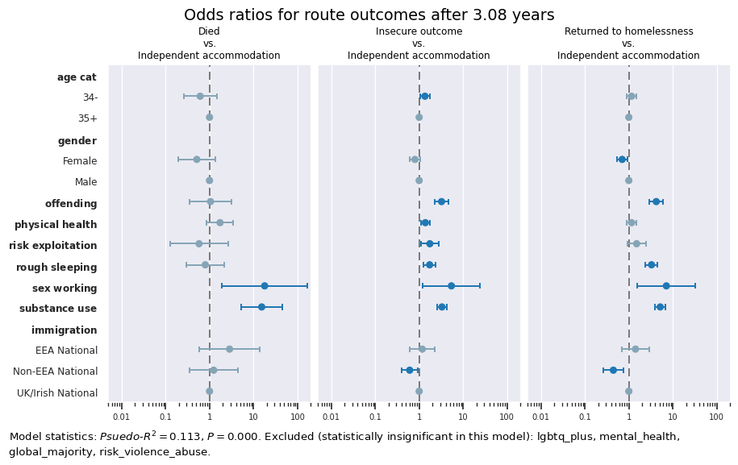

```python
figure_minor_i += 1
ref_cats_used = {k: v for k, v in ref_cats.items() if k in iv_cols_used and v[-6:] != "_False"}
shorter_iv = {r"uk\ immigration\ status": "immigration"}
fig_str = plot_odds_r(dv_str, dv.cat.categories[0], ref_cats_used, results_or_final, replacements=shorter_iv)
plt.show(block=False)
```

# Outcomes 3.08 years after a person’s first route started

## Prepare DV

```python
import statsmodels.api as sm
from statsmodels.stats.outliers_influence import variance_inflation_factor as sm_vif

# Get DV
dv_str = "Outcomes 3.08 years after a person's first route started"
dv = dv_dict[dv_str].iloc[:, 0].astype("category")
dv = dv.cat.reorder_categories(['Independent accommodation', 'Insecure outcome', 'Returned to homelessness', 'Died'])
```

## Prepare IVs

```python
cols_to_exclude = ["pway_lvl", "referral_agency", "multiple_disadvantage"]
X, Xc, iv_df, iv_cols_used, ref_cats, binaries = get_ivs(dv, cols_to_exclude)
iv_df_used = iv_df[iv_cols_used]
iv_df_used = iv_df_used.dropna()
# Ensure relevant variables exclude cases where results are NA
X = X.loc[iv_df_used.index]
Xc = Xc.loc[iv_df_used.index]
dv = dv.loc[iv_df_used.index]
```